# Description

# Overfitting

```
Accuracy:0.896
             precision    recall  f1-score   support

      title       0.46      0.97      0.62       479
     author       0.06      0.90      0.12       303
       date       0.12      1.00      0.21       248
 unassigned       1.00      0.90      0.94     60478

avg / total       0.99      0.90      0.93     61508

[[  466     5     0     8]
 [    6   274     2    21]
 [    0     0   247     1]
 [  541  3965  1828 54144]]
```

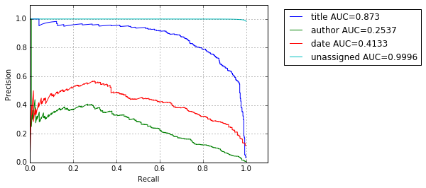

```
NN Test
Accuracy:0.900
             precision    recall  f1-score   support

      title       0.50      0.96      0.66       204
     author       0.06      0.85      0.11       124
       date       0.16      0.97      0.27       103
 unassigned       1.00      0.90      0.95     24180

avg / total       0.99      0.90      0.94     24611

[[  196     3     1     4]
 [    1   106     3    14]
 [    0     0   100     3]
 [  197  1699   538 21746]]
```

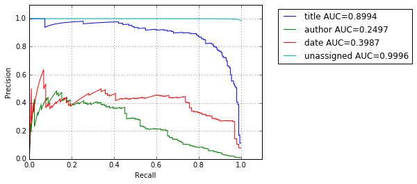

```
RF Train
Accuracy:0.997
             precision    recall  f1-score   support

      title       0.95      0.93      0.94       479
     author       0.99      0.71      0.83       303
       date       0.97      0.81      0.89       248
 unassigned       1.00      1.00      1.00     60478

avg / total       1.00      1.00      1.00     61508

[[  446     0     0    33]
 [    0   216     0    87]
 [    0     0   202    46]
 [   25     2     6 60445]]
```

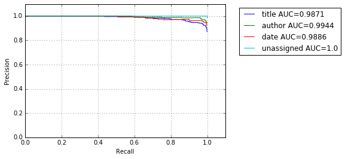

```
RF Test
Accuracy:0.992
             precision    recall  f1-score   support

      title       0.89      0.84      0.86       204
     author       0.94      0.25      0.39       124
       date       0.86      0.54      0.67       103
 unassigned       0.99      1.00      1.00     24180

avg / total       0.99      0.99      0.99     24611

[[  171     0     0    33]
 [    0    31     1    92]
 [    0     0    56    47]
 [   21     2     8 24149]]
```

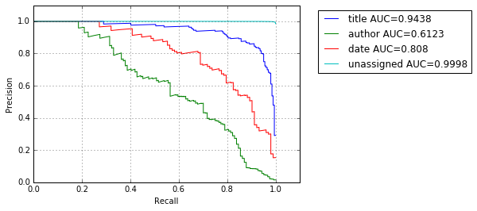

```
Merge Train
Accuracy:0.987
             precision    recall  f1-score   support

      title       0.76      0.98      0.85       479
     author       0.45      0.91      0.61       303
       date       0.44      0.99      0.61       248
 unassigned       1.00      0.99      0.99     60478

avg / total       0.99      0.99      0.99     61508

[[  468     2     0     9]
 [    4   275     2    22]
 [    0     0   246     2]
 [  145   329   309 59695]]
```

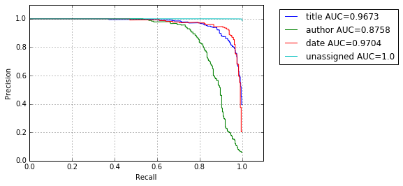

```
Merge Test
Accuracy:0.981
             precision    recall  f1-score   support

      title       0.75      0.94      0.83       204
     author       0.30      0.69      0.42       124
       date       0.40      0.91      0.56       103
 unassigned       1.00      0.98      0.99     24180

avg / total       0.99      0.98      0.98     24611

[[  192     0     1    11]
 [    1    86     3    34]
 [    0     0    94     9]
 [   63   200   135 23782]]
```

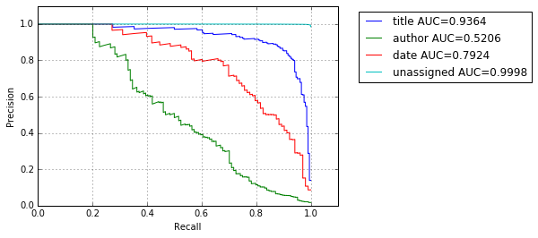

```python
%matplotlib inline

train_full = feature_frame[mask&feature_frame['instance'].isin(list(set(train['instance'])))]
X_train_full = train_full[keep_features].fillna(0).as_matrix()
y_train_full = np.array(list(train_full['label']))

predictions_nn1t = model_nn1.predict_proba(X_train_full)
predictframe_nn1t = eva.get_predictframe(predictions_nn1t, global_idxmax=True, plabel_idxmax=True, testfrm=train_full)
with warnings.catch_warnings():
    warnings.simplefilter('ignore', DeprecationWarning)
    predictions_rft  = clf.predict_proba(X_train_full)
    predictframe_rft = eva.get_predictframe(predictions_rft, global_idxmax=True, plabel_idxmax=True, testfrm=train_full)

predictions_merget = (predictions_nn1t+predictions_rft)/2
predictframe_merget = eva.get_predictframe(predictions_merget, global_idxmax=True, plabel_idxmax=True, testfrm=train_full)

predictions_nn1 = model_nn1.predict_proba(X_test)
predictframe_nn1 = eva.get_predictframe(predictions_nn1, global_idxmax=True, plabel_idxmax=True, testfrm=test)
with warnings.catch_warnings():
    warnings.simplefilter('ignore', DeprecationWarning)
    predictions_rf  = clf.predict_proba(X_test)
    predictframe_rf = eva.get_predictframe(predictions_rf, global_idxmax=True, plabel_idxmax=True, testfrm=test)

predictions_merge = (predictions_nn1+predictions_rf)/2
predictframe_merge = eva.get_predictframe(predictions_merge, global_idxmax=True, plabel_idxmax=True, testfrm=test)

print('NN Train')
eva.measure_performance(None, y_train_full, predictions_nn1t, show_curves=True)
print('NN Test')
eva.measure_performance(None, y_test, predictions_nn1, show_curves=True)
print('RF Train')
eva.measure_performance(None, y_train_full, predictions_rft, show_curves=True)
print('RF Test')
eva.measure_performance(None, y_test, predictions_rf, show_curves=True)
print('Merge Train')
eva.measure_performance(None, y_train_full, predictions_merget, show_curves=True)
print('Merge Test')
eva.measure_performance(None, y_test, predictions_merge, show_curves=True)
```

# completely correct pages

## gold

```
raw
Accuracy:0.981
             precision    recall  f1-score   support

      title       0.75      0.94      0.83       204
     author       0.30      0.69      0.42       124
       date       0.40      0.91      0.56       103
 unassigned       1.00      0.98      0.99     24180

avg / total       0.99      0.98      0.98     24611

[[  192     0     1    11]
 [    1    86     3    34]
 [    0     0    94     9]
 [   63   200   135 23782]]
```

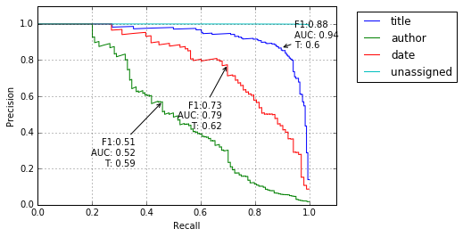

```
0.604858736829
0.58911553505
0.621165602639
Accuracy:0.993
             precision    recall  f1-score   support

      title       0.94      0.86      0.90       204
     author       0.63      0.45      0.53       124
       date       0.90      0.67      0.77       103
 unassigned       0.99      1.00      1.00     24180

avg / total       0.99      0.99      0.99     24611

[[  176     0     0    28]
 [    0    56     2    66]
 [    0     0    69    34]
 [   12    33     6 24129]]
```

```python
predictions_merge = (predictions_nn1+predictions_rf)/2
ps, predictframe_merge = doeval(predictions_merge, y_test, test,raw_frame, cnt_frm)
predictframe_merge['flab'] = ps
```

```python
def getnums(i, inst, lab):
    return {
        'instance': i,
        'label': lab,
        'has': len(inst[inst['label']==lab]),
        'found': len(inst[inst['flab']==lab]),
        'correct': len(inst[(inst['label']==lab)&(inst['flab']==lab)]),
        'diff': len(inst[((inst['label']!=lab)&(inst['flab']==lab))|
                         ((inst['label']==lab)&(inst['flab']!=lab))])
    }

tmp = []
for i, inst in predictframe_merge.groupby('instance'):
    print('==== inst {} ====='.format(i))
    ttmp = getnums(i, inst, 0)
    tmp.append(ttmp)
    print('TITLE  : has: {has}, found: {found}, correct: {correct}, diff: {diff}'.format(**ttmp))
    ttmp = getnums(i, inst, 1)
    tmp.append(ttmp)
    print('AUTHOR : has: {has}, found: {found}, correct: {correct}, diff: {diff}'.format(**ttmp))
    ttmp = getnums(i, inst, 2)
    tmp.append(ttmp)
    print('DATE   : has: {has}, found: {found}, correct: {correct}, diff: {diff}'.format(**ttmp))

allfrm = pd.DataFrame(tmp)
```

```
==== inst 0.0 =====
TITLE  : has: 1, found: 1, correct: 1, diff: 0
AUTHOR : has: 1, found: 0, correct: 0, diff: 1
DATE   : has: 1, found: 1, correct: 1, diff: 0
==== inst 2.0 =====
TITLE  : has: 1, found: 0, correct: 0, diff: 1
AUTHOR : has: 0, found: 0, correct: 0, diff: 0
DATE   : has: 0, found: 0, correct: 0, diff: 0
==== inst 3.0 =====
TITLE  : has: 1, found: 1, correct: 1, diff: 0
AUTHOR : has: 0, found: 0, correct: 0, diff: 0
DATE   : has: 1, found: 1, correct: 1, diff: 0
==== inst 10.0 =====
TITLE  : has: 1, found: 1, correct: 1, diff: 0
AUTHOR : has: 2, found: 2, correct: 2, diff: 0
DATE   : has: 1, found: 1, correct: 1, diff: 0
==== inst 13.0 =====
TITLE  : has: 1, found: 1, correct: 1, diff: 0
AUTHOR : has: 1, found: 0, correct: 0, diff: 1
DATE   : has: 1, found: 1, correct: 1, diff: 0
==== inst 19.0 =====
TITLE  : has: 1, found: 1, correct: 1, diff: 0
AUTHOR : has: 0, found: 0, correct: 0, diff: 0
DATE   : has: 1, found: 1, correct: 1, diff: 0
==== inst 22.0 =====
TITLE  : has: 1, found: 1, correct: 1, diff: 0
AUTHOR : has: 1, found: 1, correct: 1, diff: 0
DATE   : has: 1, found: 1, correct: 1, diff: 0
==== inst 23.0 =====
TITLE  : has: 1, found: 1, correct: 1, diff: 0
AUTHOR : has: 2, found: 0, correct: 0, diff: 2
DATE   : has: 1, found: 0, correct: 0, diff: 1
==== inst 26.0 =====
TITLE  : has: 1, found: 1, correct: 0, diff: 2
AUTHOR : has: 0, found: 1, correct: 0, diff: 1
DATE   : has: 1, found: 0, correct: 0, diff: 1
==== inst 27.0 =====
TITLE  : has: 1, found: 1, correct: 1, diff: 0
AUTHOR : has: 0, found: 0, correct: 0, diff: 0
DATE   : has: 0, found: 0, correct: 0, diff: 0
```

[output cut: 761 more lines]

```
TITLE  : has: 1, found: 1, correct: 1, diff: 0
AUTHOR : has: 1, found: 1, correct: 1, diff: 0
DATE   : has: 0, found: 0, correct: 0, diff: 0
==== inst 758.0 =====
TITLE  : has: 1, found: 1, correct: 1, diff: 0
AUTHOR : has: 1, found: 2, correct: 1, diff: 1
DATE   : has: 1, found: 1, correct: 1, diff: 0
==== inst 764.0 =====
TITLE  : has: 1, found: 1, correct: 1, diff: 0
AUTHOR : has: 4, found: 4, correct: 4, diff: 0
DATE   : has: 1, found: 1, correct: 1, diff: 0
==== inst 767.0 =====
TITLE  : has: 1, found: 1, correct: 1, diff: 0
AUTHOR : has: 1, found: 0, correct: 0, diff: 1
DATE   : has: 1, found: 1, correct: 1, diff: 0
```

```python
allfrmsum = allfrm.groupby('instance').sum()
allfrmsum.groupby('diff').count()
```

| diff | correct | found | has | label |
| --- | --- | --- | --- | --- |
| 0 | 86 | 86 | 86 | 86 |
| 1 | 77 | 77 | 77 | 77 |
| 2 | 25 | 25 | 25 | 25 |
| 3 | 8 | 8 | 8 | 8 |
| 4 | 8 | 8 | 8 | 8 |

```python
allfrm['diffc'] = allfrm['diff'].clip(upper=1)
allfrm[allfrm['instance'].isin(allfrmsum[allfrmsum['diff']>0].index)].groupby('label').sum()
```

| label | correct | diff | found | has | instance | diffc |
| --- | --- | --- | --- | --- | --- | --- |
| 0 | 90 | 40 | 102 | 118 | 42536.0 | 28 |
| 1 | 13 | 101 | 46 | 81 | 42536.0 | 84 |
| 2 | 35 | 42 | 43 | 69 | 42536.0 | 38 |

```python
print('pages total:', len(set(allfrm['instance'])))
print('pages with correct title:', len([i for i, inst in allfrm[allfrm['diff']==0].groupby('instance') \
                                               if len(inst[(inst['label']==0)])>0 and
                                                  len(inst[(inst['label']==1)])>=0 and
                                                  len(inst[(inst['label']==2)])>=0]))
print('pages with correct author:', len([i for i, inst in allfrm[allfrm['diff']==0].groupby('instance') \
                                               if len(inst[(inst['label']==0)])>=0 and
                                                  len(inst[(inst['label']==1)])>0 and
                                                  len(inst[(inst['label']==2)])>=0]))
print('pages with correct date:', len([i for i, inst in allfrm[allfrm['diff']==0].groupby('instance') \
                                               if len(inst[(inst['label']==0)])>=0 and
                                                  len(inst[(inst['label']==1)])>=0 and
                                                  len(inst[(inst['label']==2)])>0]))
print('pages with correct title & date:', len([i for i, inst in allfrm[allfrm['diff']==0].groupby('instance') \
                                               if len(inst[(inst['label']==0)])>0 and
                                                  len(inst[(inst['label']==1)])>=0 and
                                                  len(inst[(inst['label']==2)])>0]))

print('pages with correct title & author:', len([i for i, inst in allfrm[allfrm['diff']==0].groupby('instance') \
                                               if len(inst[(inst['label']==0)])>0 and
                                                  len(inst[(inst['label']==1)])>0 and
                                                  len(inst[(inst['label']==2)])>=0]))
print('pages with correct title & author & date:', len([i for i, inst in allfrm[allfrm['diff']==0].groupby('instance') \
                                               if len(inst[(inst['label']==0)])>0 and
                                                  len(inst[(inst['label']==1)])>0 and
                                                  len(inst[(inst['label']==2)])>0]))
print('pages with correct author & date:', len([i for i, inst in allfrm[allfrm['diff']==0].groupby('instance') \
                                               if len(inst[(inst['label']==0)])>=0 and
                                                  len(inst[(inst['label']==1)])>0 and
                                                  len(inst[(inst['label']==2)])>0]))

#[[  176     0     0    28]
# [    0    56     2    66]
# [    0     0    69    34]
# [   12    33     6 24129]]
```

```
pages total: 204
pages with correct title: 176
pages with correct author: 120
pages with correct date: 166
pages with correct title & date: 144
pages with correct title & author: 103
pages with correct title & author & date: 86
pages with correct author & date: 102
```

### with raw

```python
def getnums(i, inst, lab):
    return {
        'instance': i,
        'label': lab,
        'has': len(inst[inst['label']==lab]),
        'found': len(inst[inst['plabel']==lab]),
        'correct': len(inst[(inst['label']==lab)&(inst['plabel']==lab)]),
        'diff': len(inst[((inst['label']!=lab)&(inst['plabel']==lab))|
                         ((inst['label']==lab)&(inst['plabel']!=lab))])
    }

tmp = []
for i, inst in predictframe_nn1.groupby('instance'):
    print('==== inst {} ====='.format(i))
    ttmp = getnums(i, inst, 0)
    tmp.append(ttmp)
    print('TITLE  : has: {has}, found: {found}, correct: {correct}, diff: {diff}'.format(**ttmp))
    ttmp = getnums(i, inst, 1)
    tmp.append(ttmp)
    print('AUTHOR : has: {has}, found: {found}, correct: {correct}, diff: {diff}'.format(**ttmp))
    ttmp = getnums(i, inst, 2)
    tmp.append(ttmp)
    print('DATE   : has: {has}, found: {found}, correct: {correct}, diff: {diff}'.format(**ttmp))

allfrmr = pd.DataFrame(tmp)
```

```
==== inst 0.0 =====
TITLE  : has: 1, found: 2, correct: 1, diff: 1
AUTHOR : has: 1, found: 10, correct: 1, diff: 9
DATE   : has: 1, found: 3, correct: 1, diff: 2
==== inst 2.0 =====
TITLE  : has: 1, found: 4, correct: 0, diff: 5
AUTHOR : has: 0, found: 6, correct: 0, diff: 6
DATE   : has: 0, found: 1, correct: 0, diff: 1
==== inst 3.0 =====
TITLE  : has: 1, found: 1, correct: 1, diff: 0
AUTHOR : has: 0, found: 4, correct: 0, diff: 4
DATE   : has: 1, found: 2, correct: 1, diff: 1
==== inst 10.0 =====
TITLE  : has: 1, found: 2, correct: 1, diff: 1
AUTHOR : has: 2, found: 15, correct: 2, diff: 13
DATE   : has: 1, found: 2, correct: 1, diff: 1
==== inst 13.0 =====
TITLE  : has: 1, found: 1, correct: 1, diff: 0
AUTHOR : has: 1, found: 7, correct: 1, diff: 6
DATE   : has: 1, found: 7, correct: 1, diff: 6
==== inst 19.0 =====
TITLE  : has: 1, found: 1, correct: 1, diff: 0
AUTHOR : has: 0, found: 1, correct: 0, diff: 1
DATE   : has: 1, found: 1, correct: 1, diff: 0
==== inst 22.0 =====
TITLE  : has: 1, found: 1, correct: 1, diff: 0
AUTHOR : has: 1, found: 10, correct: 1, diff: 9
DATE   : has: 1, found: 3, correct: 1, diff: 2
==== inst 23.0 =====
TITLE  : has: 1, found: 1, correct: 1, diff: 0
AUTHOR : has: 2, found: 5, correct: 0, diff: 7
DATE   : has: 1, found: 4, correct: 1, diff: 3
==== inst 26.0 =====
TITLE  : has: 1, found: 5, correct: 1, diff: 4
AUTHOR : has: 0, found: 8, correct: 0, diff: 8
DATE   : has: 1, found: 3, correct: 1, diff: 2
==== inst 27.0 =====
TITLE  : has: 1, found: 1, correct: 1, diff: 0
AUTHOR : has: 0, found: 3, correct: 0, diff: 3
DATE   : has: 0, found: 8, correct: 0, diff: 8
```

[output cut: 761 more lines]

```
TITLE  : has: 1, found: 1, correct: 1, diff: 0
AUTHOR : has: 1, found: 26, correct: 1, diff: 25
DATE   : has: 0, found: 1, correct: 0, diff: 1
==== inst 758.0 =====
TITLE  : has: 1, found: 1, correct: 1, diff: 0
AUTHOR : has: 1, found: 15, correct: 1, diff: 14
DATE   : has: 1, found: 3, correct: 1, diff: 2
==== inst 764.0 =====
TITLE  : has: 1, found: 1, correct: 1, diff: 0
AUTHOR : has: 4, found: 10, correct: 4, diff: 6
DATE   : has: 1, found: 5, correct: 1, diff: 4
==== inst 767.0 =====
TITLE  : has: 1, found: 3, correct: 1, diff: 2
AUTHOR : has: 1, found: 2, correct: 0, diff: 3
DATE   : has: 1, found: 2, correct: 1, diff: 1
```

```python
print('pages total:', len(set(allfrm['instance'])))
print('pages with correct title:', len([i for i, inst in allfrmr[allfrmr['diff']==0].groupby('instance') \
                                               if len(inst[(inst['label']==0)])>0 and
                                                  len(inst[(inst['label']==1)])>=0 and
                                                  len(inst[(inst['label']==2)])>=0]))
print('pages with correct author:', len([i for i, inst in allfrmr[allfrmr['diff']==0].groupby('instance') \
                                               if len(inst[(inst['label']==0)])>=0 and
                                                  len(inst[(inst['label']==1)])>0 and
                                                  len(inst[(inst['label']==2)])>=0]))
print('pages with correct date:', len([i for i, inst in allfrmr[allfrmr['diff']==0].groupby('instance') \
                                               if len(inst[(inst['label']==0)])>=0 and
                                                  len(inst[(inst['label']==1)])>=0 and
                                                  len(inst[(inst['label']==2)])>0]))
print('pages with correct title & date:', len([i for i, inst in allfrmr[allfrmr['diff']==0].groupby('instance') \
                                               if len(inst[(inst['label']==0)])>0 and
                                                  len(inst[(inst['label']==1)])>=0 and
                                                  len(inst[(inst['label']==2)])>0]))

print('pages with correct title & author:', len([i for i, inst in allfrmr[allfrmr['diff']==0].groupby('instance') \
                                               if len(inst[(inst['label']==0)])>0 and
                                                  len(inst[(inst['label']==1)])>0 and
                                                  len(inst[(inst['label']==2)])>=0]))
print('pages with correct title & author & date:', len([i for i, inst in allfrmr[allfrmr['diff']==0].groupby('instance') \
                                               if len(inst[(inst['label']==0)])>0 and
                                                  len(inst[(inst['label']==1)])>0 and
                                                  len(inst[(inst['label']==2)])>0]))
print('pages with correct author & date:', len([i for i, inst in allfrmr[allfrmr['diff']==0].groupby('instance') \
                                               if len(inst[(inst['label']==0)])>=0 and
                                                  len(inst[(inst['label']==1)])>0 and
                                                  len(inst[(inst['label']==2)])>0]))
```

```
pages total: 204
pages with correct title: 87
pages with correct author: 7
pages with correct date: 71
pages with correct title & date: 30
pages with correct title & author: 7
pages with correct title & author & date: 6
pages with correct author & date: 6
```

```python
allfrmsumr = allfrmr.groupby('instance').sum()
allfrmsumr.groupby('diff').count()
```

| diff | correct | found | has | label |
| --- | --- | --- | --- | --- |
| 0 | 6 | 6 | 6 | 6 |
| 1 | 6 | 6 | 6 | 6 |
| 2 | 11 | 11 | 11 | 11 |
| 3 | 5 | 5 | 5 | 5 |
| 4 | 4 | 4 | 4 | 4 |
| 5 | 16 | 16 | 16 | 16 |
| 6 | 9 | 9 | 9 | 9 |
| 7 | 9 | 9 | 9 | 9 |
| 8 | 7 | 7 | 7 | 7 |
| 9 | 6 | 6 | 6 | 6 |
| 10 | 16 | 16 | 16 | 16 |
| 11 | 9 | 9 | 9 | 9 |
| 12 | 13 | 13 | 13 | 13 |
| 13 | 9 | 9 | 9 | 9 |
| 14 | 9 | 9 | 9 | 9 |
| 15 | 11 | 11 | 11 | 11 |
| 16 | 10 | 10 | 10 | 10 |
| 17 | 6 | 6 | 6 | 6 |
| 18 | 5 | 5 | 5 | 5 |
| 19 | 5 | 5 | 5 | 5 |
| 20 | 7 | 7 | 7 | 7 |
| 21 | 6 | 6 | 6 | 6 |
| 22 | 1 | 1 | 1 | 1 |
| 23 | 2 | 2 | 2 | 2 |
| 24 | 1 | 1 | 1 | 1 |
| 25 | 2 | 2 | 2 | 2 |
| 26 | 1 | 1 | 1 | 1 |
| 27 | 1 | 1 | 1 | 1 |
| 28 | 3 | 3 | 3 | 3 |
| 29 | 1 | 1 | 1 | 1 |
| 30 | 1 | 1 | 1 | 1 |
| 32 | 1 | 1 | 1 | 1 |
| 36 | 1 | 1 | 1 | 1 |
| 38 | 1 | 1 | 1 | 1 |
| 39 | 1 | 1 | 1 | 1 |
| 42 | 1 | 1 | 1 | 1 |
| 44 | 1 | 1 | 1 | 1 |

```python
allfrmr['diffc'] = allfrmr['diff'].clip(upper=1)
allfrmr[allfrmr['instance'].isin(allfrmsumr[allfrmsumr['diff']>0].index)].groupby('label').sum()
```

| label | correct | diff | found | has | instance | diffc |
| --- | --- | --- | --- | --- | --- | --- |
| 0 | 190 | 206 | 388 | 198 | 71934.0 | 117 |
| 1 | 102 | 1720 | 1804 | 120 | 71934.0 | 197 |
| 2 | 98 | 545 | 640 | 101 | 71934.0 | 133 |

### with raw merge

```python
def getnums(i, inst, lab):
    return {
        'instance': i,
        'label': lab,
        'has': len(inst[inst['label']==lab]),
        'found': len(inst[inst['plabel']==lab]),
        'correct': len(inst[(inst['label']==lab)&(inst['plabel']==lab)]),
        'diff': len(inst[((inst['label']!=lab)&(inst['plabel']==lab))|
                         ((inst['label']==lab)&(inst['plabel']!=lab))])
    }

tmp = []
for i, inst in predictframe_merge.groupby('instance'):
    print('==== inst {} ====='.format(i))
    ttmp = getnums(i, inst, 0)
    tmp.append(ttmp)
    print('TITLE  : has: {has}, found: {found}, correct: {correct}, diff: {diff}'.format(**ttmp))
    ttmp = getnums(i, inst, 1)
    tmp.append(ttmp)
    print('AUTHOR : has: {has}, found: {found}, correct: {correct}, diff: {diff}'.format(**ttmp))
    ttmp = getnums(i, inst, 2)
    tmp.append(ttmp)
    print('DATE   : has: {has}, found: {found}, correct: {correct}, diff: {diff}'.format(**ttmp))

allfrmm = pd.DataFrame(tmp)
```

```
==== inst 0.0 =====
TITLE  : has: 1, found: 1, correct: 1, diff: 0
AUTHOR : has: 1, found: 1, correct: 1, diff: 0
DATE   : has: 1, found: 3, correct: 1, diff: 2
==== inst 2.0 =====
TITLE  : has: 1, found: 1, correct: 0, diff: 2
AUTHOR : has: 0, found: 1, correct: 0, diff: 1
DATE   : has: 0, found: 1, correct: 0, diff: 1
==== inst 3.0 =====
TITLE  : has: 1, found: 1, correct: 1, diff: 0
AUTHOR : has: 0, found: 2, correct: 0, diff: 2
DATE   : has: 1, found: 1, correct: 1, diff: 0
==== inst 10.0 =====
TITLE  : has: 1, found: 1, correct: 1, diff: 0
AUTHOR : has: 2, found: 2, correct: 2, diff: 0
DATE   : has: 1, found: 2, correct: 1, diff: 1
==== inst 13.0 =====
TITLE  : has: 1, found: 1, correct: 1, diff: 0
AUTHOR : has: 1, found: 4, correct: 1, diff: 3
DATE   : has: 1, found: 6, correct: 1, diff: 5
==== inst 19.0 =====
TITLE  : has: 1, found: 1, correct: 1, diff: 0
AUTHOR : has: 0, found: 1, correct: 0, diff: 1
DATE   : has: 1, found: 1, correct: 1, diff: 0
==== inst 22.0 =====
TITLE  : has: 1, found: 1, correct: 1, diff: 0
AUTHOR : has: 1, found: 1, correct: 1, diff: 0
DATE   : has: 1, found: 2, correct: 1, diff: 1
==== inst 23.0 =====
TITLE  : has: 1, found: 1, correct: 1, diff: 0
AUTHOR : has: 2, found: 0, correct: 0, diff: 2
DATE   : has: 1, found: 1, correct: 1, diff: 0
==== inst 26.0 =====
TITLE  : has: 1, found: 2, correct: 1, diff: 1
AUTHOR : has: 0, found: 3, correct: 0, diff: 3
DATE   : has: 1, found: 2, correct: 1, diff: 1
==== inst 27.0 =====
TITLE  : has: 1, found: 1, correct: 1, diff: 0
AUTHOR : has: 0, found: 0, correct: 0, diff: 0
DATE   : has: 0, found: 0, correct: 0, diff: 0
```

[output cut: 761 more lines]

```
TITLE  : has: 1, found: 1, correct: 1, diff: 0
AUTHOR : has: 1, found: 4, correct: 1, diff: 3
DATE   : has: 0, found: 0, correct: 0, diff: 0
==== inst 758.0 =====
TITLE  : has: 1, found: 1, correct: 1, diff: 0
AUTHOR : has: 1, found: 5, correct: 1, diff: 4
DATE   : has: 1, found: 1, correct: 1, diff: 0
==== inst 764.0 =====
TITLE  : has: 1, found: 1, correct: 1, diff: 0
AUTHOR : has: 4, found: 5, correct: 4, diff: 1
DATE   : has: 1, found: 2, correct: 1, diff: 1
==== inst 767.0 =====
TITLE  : has: 1, found: 1, correct: 1, diff: 0
AUTHOR : has: 1, found: 1, correct: 0, diff: 2
DATE   : has: 1, found: 1, correct: 1, diff: 0
```

```python
print('pages total:', len(set(allfrm['instance'])))
print('pages with correct title:', len([i for i, inst in allfrmm[allfrmm['diff']==0].groupby('instance') \
                                               if len(inst[(inst['label']==0)])>0 and
                                                  len(inst[(inst['label']==1)])>=0 and
                                                  len(inst[(inst['label']==2)])>=0]))
print('pages with correct author:', len([i for i, inst in allfrmm[allfrmm['diff']==0].groupby('instance') \
                                               if len(inst[(inst['label']==0)])>=0 and
                                                  len(inst[(inst['label']==1)])>0 and
                                                  len(inst[(inst['label']==2)])>=0]))
print('pages with correct date:', len([i for i, inst in allfrmm[allfrmm['diff']==0].groupby('instance') \
                                               if len(inst[(inst['label']==0)])>=0 and
                                                  len(inst[(inst['label']==1)])>=0 and
                                                  len(inst[(inst['label']==2)])>0]))
print('pages with correct title & date:', len([i for i, inst in allfrmm[allfrmm['diff']==0].groupby('instance') \
                                               if len(inst[(inst['label']==0)])>0 and
                                                  len(inst[(inst['label']==1)])>=0 and
                                                  len(inst[(inst['label']==2)])>0]))

print('pages with correct title & author:', len([i for i, inst in allfrmm[allfrmm['diff']==0].groupby('instance') \
                                               if len(inst[(inst['label']==0)])>0 and
                                                  len(inst[(inst['label']==1)])>0 and
                                                  len(inst[(inst['label']==2)])>=0]))
print('pages with correct title & author & date:', len([i for i, inst in allfrmm[allfrmm['diff']==0].groupby('instance') \
                                               if len(inst[(inst['label']==0)])>0 and
                                                  len(inst[(inst['label']==1)])>0 and
                                                  len(inst[(inst['label']==2)])>0]))
print('pages with correct author & date:', len([i for i, inst in allfrmm[allfrmm['diff']==0].groupby('instance') \
                                               if len(inst[(inst['label']==0)])>=0 and
                                                  len(inst[(inst['label']==1)])>0 and
                                                  len(inst[(inst['label']==2)])>0]))
```

```
pages total: 204
pages with correct title: 143
pages with correct author: 86
pages with correct date: 129
pages with correct title & date: 92
pages with correct title & author: 63
pages with correct title & author & date: 41
pages with correct author & date: 58
```

```python
allfrmsumm = allfrmm.groupby('instance').sum()
allfrmsumm.groupby('diff').count()
```

| diff | correct | found | has | label |
| --- | --- | --- | --- | --- |
| 0 | 41 | 41 | 41 | 41 |
| 1 | 57 | 57 | 57 | 57 |
| 2 | 44 | 44 | 44 | 44 |
| 3 | 24 | 24 | 24 | 24 |
| 4 | 11 | 11 | 11 | 11 |
| 5 | 10 | 10 | 10 | 10 |
| 6 | 6 | 6 | 6 | 6 |
| 7 | 2 | 2 | 2 | 2 |
| 8 | 3 | 3 | 3 | 3 |
| 9 | 1 | 1 | 1 | 1 |
| 10 | 1 | 1 | 1 | 1 |
| 11 | 1 | 1 | 1 | 1 |
| 14 | 1 | 1 | 1 | 1 |
| 15 | 1 | 1 | 1 | 1 |
| 18 | 1 | 1 | 1 | 1 |

## eval

```
raw
Accuracy:0.981
             precision    recall  f1-score   support

      title       0.68      0.90      0.77        82
     author       0.24      0.57      0.34        44
       date       0.29      0.86      0.43        36
 unassigned       1.00      0.98      0.99     11219

avg / total       0.99      0.98      0.98     11381

[[   74     0     0     8]
 [    1    25     2    16]
 [    0     0    31     5]
 [   34    79    75 11031]]
```

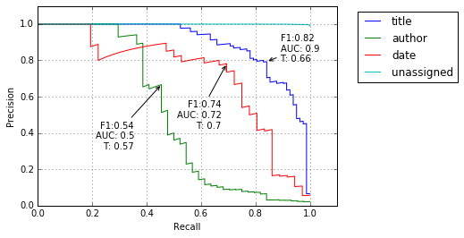

```
0.663119579616
0.573568880513
0.702120989196
Accuracy:0.993
             precision    recall  f1-score   support

      title       0.87      0.79      0.83        82
     author       0.65      0.30      0.41        44
       date       0.92      0.67      0.77        36
 unassigned       0.99      1.00      1.00     11219

avg / total       0.99      0.99      0.99     11381

[[   65     0     0    17]
 [    0    13     1    30]
 [    0     0    24    12]
 [   10     7     1 11201]]
```

```python
#teste, _, _, _, _, X_e, y_e, Y_e
predictions_mergee = pred_merge_e
ps, predictframe_mergee = doeval(predictions_mergee, y_e, teste, raw_framee, cnt_frme)
predictframe_mergee['flab'] = ps
```

```python
def getnums(i, inst, lab):
    return {
        'instance': i,
        'label': lab,
        'has': len(inst[inst['label']==lab]),
        'found': len(inst[inst['flab']==lab]),
        'correct': len(inst[(inst['label']==lab)&(inst['flab']==lab)]),
        'diff': len(inst[((inst['label']!=lab)&(inst['flab']==lab))|
                         ((inst['label']==lab)&(inst['flab']!=lab))])
    }

tmp = []
for i, inst in predictframe_mergee.groupby('instance'):
    print('==== inst {} ====='.format(i))
    ttmp = getnums(i, inst, 0)
    tmp.append(ttmp)
    print('TITLE  : has: {has}, found: {found}, correct: {correct}, diff: {diff}'.format(**ttmp))
    ttmp = getnums(i, inst, 1)
    tmp.append(ttmp)
    print('AUTHOR : has: {has}, found: {found}, correct: {correct}, diff: {diff}'.format(**ttmp))
    ttmp = getnums(i, inst, 2)
    tmp.append(ttmp)
    print('DATE   : has: {has}, found: {found}, correct: {correct}, diff: {diff}'.format(**ttmp))

allfrme= pd.DataFrame(tmp)
```

```
==== inst 0.0 =====
TITLE  : has: 1, found: 0, correct: 0, diff: 1
AUTHOR : has: 1, found: 0, correct: 0, diff: 1
DATE   : has: 0, found: 0, correct: 0, diff: 0
==== inst 1.0 =====
TITLE  : has: 1, found: 1, correct: 1, diff: 0
AUTHOR : has: 0, found: 0, correct: 0, diff: 0
DATE   : has: 0, found: 0, correct: 0, diff: 0
==== inst 2.0 =====
TITLE  : has: 1, found: 1, correct: 1, diff: 0
AUTHOR : has: 1, found: 0, correct: 0, diff: 1
DATE   : has: 1, found: 1, correct: 1, diff: 0
==== inst 4.0 =====
TITLE  : has: 1, found: 1, correct: 1, diff: 0
AUTHOR : has: 1, found: 1, correct: 1, diff: 0
DATE   : has: 0, found: 0, correct: 0, diff: 0
==== inst 5.0 =====
TITLE  : has: 1, found: 1, correct: 1, diff: 0
AUTHOR : has: 1, found: 0, correct: 0, diff: 1
DATE   : has: 1, found: 0, correct: 0, diff: 1
==== inst 6.0 =====
TITLE  : has: 1, found: 1, correct: 1, diff: 0
AUTHOR : has: 0, found: 1, correct: 0, diff: 1
DATE   : has: 0, found: 0, correct: 0, diff: 0
==== inst 8.0 =====
TITLE  : has: 1, found: 1, correct: 0, diff: 2
AUTHOR : has: 1, found: 0, correct: 0, diff: 1
DATE   : has: 1, found: 1, correct: 1, diff: 0
==== inst 9.0 =====
TITLE  : has: 1, found: 1, correct: 1, diff: 0
AUTHOR : has: 0, found: 0, correct: 0, diff: 0
DATE   : has: 1, found: 1, correct: 1, diff: 0
==== inst 10.0 =====
TITLE  : has: 1, found: 1, correct: 0, diff: 2
AUTHOR : has: 1, found: 0, correct: 0, diff: 1
DATE   : has: 0, found: 0, correct: 0, diff: 0
==== inst 11.0 =====
TITLE  : has: 1, found: 1, correct: 1, diff: 0
AUTHOR : has: 1, found: 1, correct: 1, diff: 0
DATE   : has: 1, found: 1, correct: 1, diff: 0
```

[output cut: 273 more lines]

```
TITLE  : has: 1, found: 1, correct: 1, diff: 0
AUTHOR : has: 2, found: 1, correct: 1, diff: 1
DATE   : has: 1, found: 1, correct: 1, diff: 0
==== inst 96.0 =====
TITLE  : has: 1, found: 1, correct: 1, diff: 0
AUTHOR : has: 0, found: 0, correct: 0, diff: 0
DATE   : has: 1, found: 0, correct: 0, diff: 1
==== inst 97.0 =====
TITLE  : has: 1, found: 1, correct: 1, diff: 0
AUTHOR : has: 1, found: 0, correct: 0, diff: 1
DATE   : has: 1, found: 1, correct: 1, diff: 0
==== inst 98.0 =====
TITLE  : has: 1, found: 1, correct: 1, diff: 0
AUTHOR : has: 1, found: 0, correct: 0, diff: 1
DATE   : has: 1, found: 0, correct: 0, diff: 1
```

```python
allfrmsume = allfrme.groupby('instance').sum()
allfrmsume.groupby('diff').count()
```

| diff | correct | found | has | label |
| --- | --- | --- | --- | --- |
| 0 | 37 | 37 | 37 | 37 |
| 1 | 18 | 18 | 18 | 18 |
| 2 | 22 | 22 | 22 | 22 |
| 3 | 4 | 4 | 4 | 4 |
| 5 | 1 | 1 | 1 | 1 |

```python
allfrme['diffc'] = allfrme['diff'].clip(upper=1)
allfrme[allfrme['instance'].isin(allfrmsume[allfrmsume['diff']>0].index)].groupby('label').sum()
```

| label | correct | diff | found | has | instance | diffc |
| --- | --- | --- | --- | --- | --- | --- |
| 0 | 28 | 27 | 38 | 45 | 2429.0 | 17 |
| 1 | 2 | 38 | 9 | 33 | 2429.0 | 30 |
| 2 | 12 | 14 | 14 | 24 | 2429.0 | 14 |

```python
print('pages total:', len(set(allfrme['instance'])))
print('pages with correct title:', len([i for i, inst in allfrme[allfrme['diff']==0].groupby('instance') \
                                               if len(inst[(inst['label']==0)])>0 and
                                                  len(inst[(inst['label']==1)])>=0 and
                                                  len(inst[(inst['label']==2)])>=0]))
print('pages with correct author:', len([i for i, inst in allfrme[allfrme['diff']==0].groupby('instance') \
                                               if len(inst[(inst['label']==0)])>=0 and
                                                  len(inst[(inst['label']==1)])>0 and
                                                  len(inst[(inst['label']==2)])>=0]))
print('pages with correct date:', len([i for i, inst in allfrme[allfrme['diff']==0].groupby('instance') \
                                               if len(inst[(inst['label']==0)])>=0 and
                                                  len(inst[(inst['label']==1)])>=0 and
                                                  len(inst[(inst['label']==2)])>0]))
print('pages with correct title & date:', len([i for i, inst in allfrme[allfrme['diff']==0].groupby('instance') \
                                               if len(inst[(inst['label']==0)])>0 and
                                                  len(inst[(inst['label']==1)])>=0 and
                                                  len(inst[(inst['label']==2)])>0]))

print('pages with correct title & author:', len([i for i, inst in allfrme[allfrme['diff']==0].groupby('instance') \
                                               if len(inst[(inst['label']==0)])>0 and
                                                  len(inst[(inst['label']==1)])>0 and
                                                  len(inst[(inst['label']==2)])>=0]))
print('pages with correct title & author & date:', len([i for i, inst in allfrme[allfrme['diff']==0].groupby('instance') \
                                               if len(inst[(inst['label']==0)])>0 and
                                                  len(inst[(inst['label']==1)])>0 and
                                                  len(inst[(inst['label']==2)])>0]))
print('pages with correct author & date:', len([i for i, inst in allfrme[allfrme['diff']==0].groupby('instance') \
                                               if len(inst[(inst['label']==0)])>=0 and
                                                  len(inst[(inst['label']==1)])>0 and
                                                  len(inst[(inst['label']==2)])>0]))

#[[   65     0     0    17]
# [    0    13     1    30]
# [    0     0    24    12]
# [   10     7     1 11201]]
```

```
pages total: 82
pages with correct title: 65
pages with correct author: 52
pages with correct date: 68
pages with correct title & date: 53
pages with correct title & author: 42
pages with correct title & author & date: 37
pages with correct author & date: 46
```

# Wrong classification

```python
# This is the reference classification
cfrm = predictframe_merge.copy()
cfrm.loc[cfrm[cfrm['tfx']==0].index, 'lab'] = 0
cfrm.loc[cfrm[cfrm['tf']==1].index,  'lab'] = 1
cfrm.loc[cfrm[cfrm['tfx']==2].index, 'lab'] = 2
cfrm['lab'].fillna(3, inplace=True)

cfrme = predfrm_merge_e.copy()
```

## Title

```python
print('FALSE POSITIVES (Test)')
fps = cfrm[(cfrm['label']!=0)&(cfrm['lab']==0)]
print(fps.shape)
for (_,a),(_,b) in zip(meta_frame.loc[fps['instance']][['title','url']].iterrows(),
               raw_frame.loc[fps.index][['text']].iterrows()):
    print('inst:',a.name,'URL:',a['url'])
    print('CORRECT:',a['title'])
    print('FOUND:', b['text'])
```

```
FALSE POSITIVES (Test)
(18, 14)
inst: 26.0 URL: http://www.ccohs.ca/oshanswers/hsprograms/hazard_risk.html
CORRECT: Hazard and Risk
FOUND: OSH Answers Fact Sheets
inst: 254.0 URL: http://www.gao.gov/products/GAO-14-778
CORRECT: Need for Affordable Strategy, Greater Attention to Risks, and Improved Cost Estimates
FOUND: F-35 Sustainment:
inst: 272.0 URL: http://bitesizebio.com/13400/a-beginners-guide-to-haematoxylin-and-eosin-staining/
CORRECT: A Beginner’s Guide to Haematoxylin and Eosin Staining
FOUND: Upcoming Webinar
inst: 292.0 URL: http://www.aqr.org.uk/glossary/brand-positioning
CORRECT: Brand positioning
FOUND: The Hub of Qualitative Thinking
inst: 297.0 URL: http://www.gao.gov/products/NSIAD-98-113
CORRECT: Requirements and Costs for Commonly Funded Projects
FOUND: NATO Enlargement:
inst: 381.0 URL: https://books.google.co.uk/books?id=jusKAwAAQBAJ&pg=PR11&lpg=PR11&dq=Svankmajer+tactile+art&source=bl&ots=Q70cv32ADH&sig=z79sylVVb79IpFCgSetmas-6iSQ&hl=en&sa=X&ved=0ahUKEwj-ne-X0qnJAhVDhA8KHZyyBjAQ6AEIWDAL#v=onepage&q=Svankmajer%20tactile%20art&f=false
CORRECT: Reviews
FOUND: Touching and Imagining: An Introduction to Tactile Art
inst: 400.0 URL: http://www.nytimes.com/2000/04/04/business/us-vs-microsoft-overview-us-judge-says-microsoft-violated-antitrust-laws-with.html?pagewanted=all
CORRECT: U.S. VS. MICROSOFT: THE OVERVIEW; U.S. JUDGE SAYS MICROSOFT VIOLATED ANTITRUST LAWS WITH PREDATORY BEHAVIOR
FOUND: Business Day
inst: 424.0 URL: http://www.neweconomics.org/publications/entry/urgent-recall
CORRECT: Urgent recall
FOUND: Publications
inst: 429.0 URL: http://personcentredcare.health.org.uk/person-centred-care/what-person-centred-care
CORRECT: What is person-centred care?
FOUND: Person-centred care resource centre
inst: 444.0 URL: http://www.webmd.com/prostate-cancer/guide/medical-team
CORRECT: Advanced Prostate Cancer: Choosing Your Medical Team
FOUND: Prostate Cancer Health Center
inst: 469.0 URL: http://www.unitiv.com/intelligent-help-desk-blog/bid/64134/New-Survey-Shows-Unhappy-Customers-Spread-the-Word
CORRECT: New Survey Shows Unhappy Customers Spread the Word
FOUND: Intelligent Help Desk Blog
inst: 502.0 URL: http://www.supplychainquarterly.com/topics/Strategy/20120622-six-steps-to-successful-supply-chain-collaboration/
CORRECT: Six steps to successful supply chain collaboration
FOUND: Strategy
inst: 629.0 URL: http://scienceaid.co.uk/psychology/social/facilitation.html
CORRECT: Social Facilitation
FOUND: Drive Theory
inst: 647.0 URL: https://wikileaks.org/afg/event/2007/06/AFG20070619n746.html
CORRECT: D3 190540Z Polish Convoy vic FOB Lightning 1x Polish wounded
FOUND: WikiLeaks
inst: 693.0 URL: http://www.english-online.at/media/emails/advantages-disadvantages-of-electronic-mail.htm
CORRECT: Emails - Advantages and Disadvantages of Electronic Mail
FOUND: English Online
inst: 703.0 URL: https://www.ted.com/talks/angela_patton_a_father_daughter_dance_in_prison/transcript?language=en#t-24339
CORRECT: A father-daughter dance ... in prison
FOUND: Subtitles and Transcript
inst: 732.0 URL: http://www.ccfc.co.uk/club/boardroom/
CORRECT: Boardroom
FOUND: Coventry City
inst: 762.0 URL: http://www.wipo.int/wipolex/en/text.jsp?file_id=225262
CORRECT: Qatar
FOUND: World Intellectual Property Organization
```

```python
print('FALSE POSITIVES')
fps = cfrme[(cfrme['label']!=0)&(cfrme['lab']==0)]
print(fps.shape)
for (_,a),(_,b) in zip(meta_framee.loc[fps['instance']][['title','url']].iterrows(),
               raw_framee.loc[fps.index][['text']].iterrows()):
    print('inst:',a.name,'URL:',a['url'])
    print('CORRECT:',a['title'])
    print('FOUND:', b['text'])
```

```
FALSE POSITIVES
(8, 12)
inst: 14.0 URL: http://www.unodc.org/toc/en/crimes/migrant-smuggling.html
CORRECT: Smuggling of migrants: the harsh search for a better life
FOUND: Transnational Organized Crime:
inst: 24.0 URL: http://www.afdc.energy.gov/fuels/ethanol_fuel_basics.html
CORRECT: Ethanol Fuel Basics
FOUND: Alternative Fuels Data Center
inst: 37.0 URL: http://www.emiratesgroupcareers.com/english/careers_overview/cargo/recruit_process.aspx
CORRECT: The Recruitment Process
FOUND: Explore our Careers
inst: 41.0 URL: http://www.valuebasedmanagement.net/methods_herzberg_two_factor_theory.html
CORRECT: Two Factor Theory
FOUND: This website uses cookies. for more info.
inst: 67.0 URL: http://www.naldic.org.uk/research-and-information/eal-statistics/eal-pupils
CORRECT: EAL pupils in schools
FOUND: The latest statistics about EAL learners in our schools
inst: 83.0 URL: http://www.transparency.org/cpi2014
CORRECT: 2014 corruption perceptions index
FOUND: See the results
inst: 87.0 URL: http://www.rsrevision.com/GCSE/christian_perspectives/life/euthanasia/bible.htm
CORRECT: The Bible and Euthanasia
FOUND: rsrevision.com/gcse
inst: 92.0 URL: http://www.biologicaldiversity.org/programs/biodiversity/elements_of_biodiversity/
CORRECT: The elements of biodiversity
FOUND: The Elements of Biodiversity
```

Test: 26: section title 254: part (container) 272: Internal ad where page banner would be 292: page title 297: part (container) 381: Annotation was wrong, found correct title 400: section title 424: section title 429: 404, found page title 444: section title 469: section title 502: section title 629: subsection title 647: page title 693: page title 703: title for the content, "correct title" is title of the talk 732: title not to be found on current page... 762: page title Eval: 14: page title 24: page title 37: section title 41: cookie info 67: part (subtitle) 83: subsection title 87: page title 92: correct title (duplicate)

```python
print('FALSE NEGATIVES')
fns = cfrm[(cfrm['label']==0)&(cfrm['lab']!=0)]
print(list(fns['instance']))
print('only care about those, where something else happened (FN see FP)')
fnsleft = list(set(fns['instance'])-set(fps['instance']))
print('difference: ', fnsleft)

for i, r in meta_frame.loc[fnsleft].iterrows():
    print(i, r['url'])
    print(r['title'])

for i, r in cfrm[(cfrm['label']==0)&(cfrm['instance'].isin(fnsleft))].iterrows():
    print('scores for actual title in instance', r['instance'])
    print(r[['title','author','issued','unassigned']])

#cfrm[(cfrm['instance'].isin(fnsleft))&(cfrm['lab']==0)]
#print(fns.shape)
#for (_,a),(_,b) in zip(meta_frame.loc[fns['instance']][['title','url']].iterrows(),
#               raw_frame.loc[fns.index][['text']].iterrows()):
#    print('inst:',a.name,'URL:',a['url'])
#    print('CORRECT:',a['title'])
```

```
FALSE NEGATIVES
[26.0, 31.0, 45.0, 254.0, 272.0, 292.0, 297.0, 381.0, 400.0, 424.0, 429.0, 444.0, 469.0, 502.0, 566.0, 570.0, 629.0, 647.0, 693.0, 703.0, 708.0, 732.0, 738.0, 755.0, 762.0]
only care about those, where something else happened (FN see FP)
difference:  [647.0, 272.0, 400.0, 26.0, 31.0, 292.0, 424.0, 297.0, 45.0, 429.0, 693.0, 566.0, 570.0, 444.0, 703.0, 708.0, 469.0, 732.0, 738.0, 755.0, 629.0, 502.0, 762.0, 381.0, 254.0]
647.0 https://wikileaks.org/afg/event/2007/06/AFG20070619n746.html
D3 190540Z Polish Convoy vic FOB Lightning 1x Polish wounded
272.0 http://bitesizebio.com/13400/a-beginners-guide-to-haematoxylin-and-eosin-staining/
A Beginner’s Guide to Haematoxylin and Eosin Staining
400.0 http://www.nytimes.com/2000/04/04/business/us-vs-microsoft-overview-us-judge-says-microsoft-violated-antitrust-laws-with.html?pagewanted=all
U.S. VS. MICROSOFT: THE OVERVIEW; U.S. JUDGE SAYS MICROSOFT VIOLATED ANTITRUST LAWS WITH PREDATORY BEHAVIOR
26.0 http://www.ccohs.ca/oshanswers/hsprograms/hazard_risk.html
Hazard and Risk
31.0 http://deathpenalty.procon.org/view.timeline.php?timelineID=000025
Historical Timeline
292.0 http://www.aqr.org.uk/glossary/brand-positioning
Brand positioning
424.0 http://www.neweconomics.org/publications/entry/urgent-recall
Urgent recall
297.0 http://www.gao.gov/products/NSIAD-98-113
Requirements and Costs for Commonly Funded Projects
45.0 https://www.youtube.com/channel/UCm1TtoxyDpfUyhemJEn14JA
WrightBower
429.0 http://personcentredcare.health.org.uk/person-centred-care/what-person-centred-care
What is person-centred care?
693.0 http://www.english-online.at/media/emails/advantages-disadvantages-of-electronic-mail.htm
Emails - Advantages and Disadvantages of Electronic Mail
566.0 https://books.google.co.uk/books?id=NNZUAAAAMAAJ
Centropa
570.0 http://www.britannica.com/technology/panzer
Panzer
444.0 http://www.webmd.com/prostate-cancer/guide/medical-team
Advanced Prostate Cancer: Choosing Your Medical Team
703.0 https://www.ted.com/talks/angela_patton_a_father_daughter_dance_in_prison/transcript?language=en#t-24339
A father-daughter dance ... in prison
708.0 http://pitchfork.com/reviews/albums/1754-shes-in-control/
Chromeo
469.0 http://www.unitiv.com/intelligent-help-desk-blog/bid/64134/New-Survey-Shows-Unhappy-Customers-Spread-the-Word
New Survey Shows Unhappy Customers Spread the Word
732.0 http://www.ccfc.co.uk/club/boardroom/
Boardroom
```

[output cut: 149 more lines]

```
issued        0.017894
unassigned    0.360782
Name: 223720, dtype: float64
scores for actual title in instance 755.0
title         0.379783
author        0.036793
issued        0.035910
unassigned    0.547514
Name: 227376, dtype: float64
scores for actual title in instance 762.0
title         0.547861
author        0.015769
issued        0.010139
unassigned    0.426231
Name: 228994, dtype: float64
```

```python
print('FALSE NEGATIVES (Eval)')
fns = cfrme[(cfrme['label']==0)&(cfrme['lab']!=0)]
print(list(fns['instance']))
print('only care about those, where something else happened (FN see FP)')
fnsleft = list(set(fns['instance'])-set(fps['instance']))
print('difference: ', fnsleft)

for i, r in meta_framee.loc[fnsleft].iterrows():
    print(i, r['url'])
    print(r['title'])

for i, r in cfrme[(cfrme['label']==0)&(cfrme['instance'].isin(fnsleft))].iterrows():
    print('scores for actual title in instance', r['instance'])
    print(r[['title','author','issued','unassigned']])
```

```
FALSE NEGATIVES (Eval)
[0.0, 14.0, 16.0, 24.0, 31.0, 37.0, 41.0, 48.0, 53.0, 60.0, 67.0, 82.0, 83.0, 87.0, 92.0]
only care about those, where something else happened (FN see FP)
difference:  [0.0, 16.0, 48.0, 82.0, 53.0, 60.0, 31.0]
0.0 http://allart.biz/photos/image/William_Holman_Hunt_10_Self_Portrait.html
Self-Portrait
16.0 http://stateofdecay.wikia.com/wiki/Feral
Feral
48.0 http://www.avivastadium.ie/stadium-info/accessibility
Accessibility
82.0 https://prezi.com/hril9re5wp9b/p1-m1-unit-37/
P1 M1 Unit 37
53.0 http://www.johnkay.com/1999/09/27/mastering-strategy-resource-based-strategy
Mastering Strategy: Resource Based Strategy
60.0 https://www.business-case-analysis.com/pricing.html
Pricing, Price/Demand Curve, Pricing Strategy, Pricing Model Explained
31.0 http://neuroscience.uth.tmc.edu/s3/chapter05.html
Chapter 5: Cerebellum
scores for actual title in instance 0.0
title         0.018459
author        0.166798
issued        0.038631
unassigned    0.776112
Name: 21, dtype: float64
scores for actual title in instance 16.0
title         0.543786
author        0.005950
issued        0.006456
unassigned    0.443809
Name: 3429, dtype: float64
scores for actual title in instance 31.0
title         0.568424
author        0.150140
issued        0.035934
unassigned    0.245502
Name: 8955, dtype: float64
scores for actual title in instance 48.0
title         0.328611
author        0.040124
issued        0.019258
unassigned    0.612007
Name: 15505, dtype: float64
scores for actual title in instance 53.0
title         0.427938
author        0.068292
issued        0.014209
unassigned    0.489561
Name: 17855, dtype: float64
scores for actual title in instance 60.0
title         0.584182
author        0.081384
issued        0.009301
unassigned    0.325133
Name: 20275, dtype: float64
scores for actual title in instance 82.0
title         0.692518
author        0.020789
issued        0.011297
unassigned    0.275397
Name: 28630, dtype: float64
```

False negatives are directly linked to false positives (obviously), otherwise no title found! Test: 755: easy for humans, surrounded by other title-like elements, needs NLP Eval: 0: Title should be title for an image, which is inside the text (table of details) 16: looks like a subtitle and is surrounded by such (three section titles in a row) 31: hm... 48: four section titles in a row, in between correct title 53: no excuse! very obvious title! 82: has a video and lots of other stuff above

```python
raw_framee[(raw_framee['instance'].isin([0,13,31,48,53, 82]))&(raw_framee['tlabel']=='0.0')].T
```

|  | 21 | 2938 | 8955 | 15505 | 17855 | 28630 |
| --- | --- | --- | --- | --- | --- | --- |
| background_color | rgba(0, 0, 0, 0) | rgba(0, 0, 0, 0) | rgba(0, 0, 0, 0) | rgba(0, 0, 0, 0) | rgb(255, 255, 255) | rgba(0, 0, 0, 0) |
| background_image | none | none | none | none | none | none |
| bounds_height | 14 | 115 | 24 | 41 | 19 | 43 |
| bounds_left | 376 | 570 | 372 | 363 | 358 | 370 |
| bounds_top | 1018 | 145 | 238 | 521 | 177 | 627 |
| bounds_width | 64 | 710 | 217 | 149 | 430 | 256 |
| class_name | colorize |  | chapterTitle | rsmLink |  |  |
| css_height | 0px | 100px | 0px | 41px | 19px | 0px |
| css_width | 0px | 710px | 0px | 149px | 430px | 0px |
| east | [] | [] | [] | [] | [] | [] |
| font_family | Arial, Tahoma, Verdana, sans-serif | 'Average Sans', Georgia, 'Times New Roman', Ti... | 'Trebuchet MS', Arial, Helvetica, sans-serif | myriad-pro, sans-serif | Calibri, Verdana, Helvetica | 'PT Sans' |
| font_size | 12px | 43px | 20px | 20px | 19px | 36px |
| font_style | normal | normal | normal | normal | normal | normal |
| font_weight | normal | normal | bold | bold | 200 | bold |
| glabel | 0 | 0 | 0 | 0 | 0 | 0 |
| html | Self-Portrait | Forensic Cases: The Murder of Leanne Tiernan | Chapter 5: Cerebellum | Accessibility | Mastering Strategy: Resource Based Strategy | P1 M1 Unit 37 |
| id |  |  |  |  |  | prezi_title |
| instance | 0 | 13 | 31 | 48 | 53 | 82 |
| json_label | TITLE | TITLE | TITLE | TITLE | TITLE | TITLE |
| label | 0 | 0 | 0 | 0 | 0 | 0 |
| margin_bottom | 0px | 0px | 0px | 0px | 15px | 10px |
| margin_left | 0px | 0px | 0px | 0px | 0px | 0px |
| margin_right | 0px | 0px | 0px | 0px | 0px | 10px |
| margin_top | 0px | 0px | 0px | 0px | 0px | 0px |
| node_type | SPAN | H1 | SPAN | A | H2 | SPAN |
| north | [] | [2936] | [] | [] | [17848, 17849, 17850, 17851, 17852] | [28626, 28627, 28628] |
| padding_bottom | 0px | 5px | 0px | 0px | 0px | 0px |
| padding_left | 0px | 0px | 0px | 0px | 0px | 0px |
| padding_right | 0px | 0px | 0px | 0px | 0px | 0px |
| padding_top | 0px | 10px | 0px | 0px | 0px | 0px |
| pos_ne_x | 440 | 1280 | 589 | 512 | 788 | 626 |
| pos_ne_y | 1018 | 145 | 238 | 521 | 177 | 627 |
| pos_nw_x | 376 | 570 | 372 | 363 | 358 | 370 |
| pos_nw_y | 1018 | 145 | 238 | 521 | 177 | 627 |
| pos_se_x | 440 | 1280 | 589 | 512 | 788 | 626 |
| pos_se_y | 1032 | 260 | 262 | 562 | 196 | 670 |
| pos_sw_x | 376 | 570 | 372 | 363 | 358 | 370 |
| pos_sw_y | 1032 | 260 | 262 | 562 | 196 | 670 |
| rules | ['html, body, div, span, applet, object, h1, h... | ['h1'] | ['.chapterTitle'] | ['html, body, div, span, applet, object, ifram... | ['#subleftcolumn h2, #subrightcolumn h2, #cont... | [] |
| south | [23] | [2939, 2940, 2941] | [8956, 8957, 8958] | [15507, 15509] | [17856] | [] |
| text | Self-Portrait | Forensic Cases: The Murder of Leanne Tiernan | Chapter 5: Cerebellum | Accessibility | Mastering Strategy: Resource Based Strategy | P1 M1 Unit 37 |
| text_align | left | -webkit-auto | left | left | left | -webkit-auto |
| tlabel | 0.0 | 0.0 | 0.0 | 0.0 | 0.0 | 0.0 |
| west | [20, 22] | [3053] | [] | [] | [] | [] |

```python
feature_framee[(feature_framee['instance'].isin([0,13,31,48,53, 82]))&(feature_framee['label']==0)][keep_features].round(3).T
```

|  | 21 | 2938 | 8955 | 15505 | 17855 | 28630 |
| --- | --- | --- | --- | --- | --- | --- |
| has_academic_title | -1.000 | -1.000 | -1.000 | -1.000 | -1.000 | -1.000 |
| avg_neighbourdist_k=2<45.0 | 0.000 | 0.000 | 0.000 | 0.000 | 0.000 | 0.000 |
| node_type=b | -1.000 | -1.000 | -1.000 | -1.000 | -1.000 | -1.000 |
| h_pos_from_mean=20-35 | 0.000 | 0.000 | 0.000 | 0.000 | 0.000 | 0.000 |
| has_uppercase | 1.000 | 1.000 | 1.000 | 1.000 | 1.000 | 1.000 |
| in_screen=1 | 1.000 | 1.000 | 1.000 | 1.000 | 1.000 | 1.000 |
| is_second_largest_font | 1.000 | 0.000 | 0.000 | 1.000 | 0.000 | 0.000 |
| text_align=center | -1.000 | -1.000 | -1.000 | -1.000 | -1.000 | -1.000 |
| width_rel>40 | -1.000 | 1.000 | -1.000 | -1.000 | -1.000 | -1.000 |
| in_quadrant=00 | -1.000 | 1.000 | 1.000 | 1.000 | 1.000 | -1.000 |
| node_type=th | -1.000 | -1.000 | -1.000 | -1.000 | -1.000 | -1.000 |
| avg_neighbourdist_k=2<80.0 | 0.000 | 0.000 | 0.000 | 1.000 | 0.000 | 1.000 |
| has_abbrev_name | -1.000 | -1.000 | -1.000 | -1.000 | -1.000 | -1.000 |
| num_chars<8 | -1.000 | -1.000 | -1.000 | -1.000 | -1.000 | -1.000 |
| font_size<mean | 0.000 | 0.000 | 0.000 | 0.000 | 0.000 | 0.000 |
| v_pos_rescaled | 0.189 | -0.992 | -0.957 | -0.589 | -0.953 | -0.647 |
| hw_ratio=portrait | -1.000 | -1.000 | -1.000 | -1.000 | -1.000 | -1.000 |
| is_smallest_font | 0.000 | 0.000 | 0.000 | 0.000 | 0.000 | 0.000 |
| nb_font_size<mean | 0.000 | 0.000 | 0.000 | 0.000 | 0.000 | 0.000 |
| num_chars<30 | 1.000 | -1.000 | 1.000 | 1.000 | -1.000 | 1.000 |
| node_type=h1 | -1.000 | 1.000 | -1.000 | -1.000 | -1.000 | -1.000 |
| has_consec_digits=4 | -1.000 | -1.000 | -1.000 | -1.000 | -1.000 | -1.000 |
| font_family=serif | 1.000 | NaN | 1.000 | 1.000 | NaN | NaN |
| in_quadrant=10 | 1.000 | -1.000 | -1.000 | -1.000 | -1.000 | 1.000 |
| font_weight=bold | -1.000 | -1.000 | 1.000 | 1.000 | -1.000 | 1.000 |
| height_standardised | -0.461 | 1.964 | -0.438 | 0.973 | -0.573 | 1.925 |
| avg_neighbourdist_k=2<220.0 | 0.000 | 0.000 | 0.000 | 0.000 | 0.000 | 0.000 |
| in_screen>6 | -1.000 | -1.000 | -1.000 | -1.000 | -1.000 | -1.000 |
| node_type=a | -1.000 | -1.000 | -1.000 | 1.000 | -1.000 | -1.000 |
| is_largest_font | 1.000 | 1.000 | 1.000 | 0.000 | 0.000 | 1.000 |
| ... | ... | ... | ... | ... | ... | ... |
| num_uppercase_words=2 | -1.000 | -1.000 | 1.000 | -1.000 | -1.000 | -1.000 |
| width_prel<10 | 1.000 | 0.000 | 0.000 | 1.000 | 0.000 | 0.000 |
| num_uppercase_words=3-5 | -1.000 | -1.000 | -1.000 | -1.000 | 1.000 | -1.000 |
| hw_ratio=landscape | -1.000 | -1.000 | -1.000 | -1.000 | -1.000 | -1.000 |
| avg_neighbourdist_k=4<210.0 | 0.000 | 0.000 | 0.000 | 0.000 | 0.000 | 0.000 |
| width_rel<10 | 1.000 | -1.000 | -1.000 | -1.000 | -1.000 | -1.000 |
| text_align=justify | -1.000 | -1.000 | -1.000 | -1.000 | -1.000 | -1.000 |
| area_rescaled | -0.987 | 0.492 | -0.946 | -0.723 | -0.852 | -0.068 |
| has_dateformat=d | -1.000 | -1.000 | -1.000 | -1.000 | -1.000 | -1.000 |
| text_align=right | -1.000 | -1.000 | -1.000 | -1.000 | -1.000 | -1.000 |
| avg_neighbourdist_k=4<170.0 | 1.000 | 0.000 | 1.000 | 1.000 | 1.000 | 0.000 |
| font_style=italic | -1.000 | -1.000 | -1.000 | -1.000 | -1.000 | -1.000 |
| node_type=span | 1.000 | -1.000 | 1.000 | -1.000 | -1.000 | 1.000 |
| font_size>>mean | 0.000 | 1.000 | 1.000 | 1.000 | 0.000 | 1.000 |
| node_type=h3 | -1.000 | -1.000 | -1.000 | -1.000 | -1.000 | -1.000 |
| num_dots | 0.000 | 0.000 | 0.000 | 0.000 | 0.000 | 0.000 |
| in_top_40 | -1.000 | -1.000 | 1.000 | -1.000 | -1.000 | -1.000 |
| avg_neighbourdist_k=2>220.0 | 0.000 | 1.000 | 0.000 | 0.000 | 0.000 | 0.000 |
| num_commas | 0.000 | 0.000 | 0.000 | 0.000 | 0.000 | 0.000 |
| in_quadrant=01 | -1.000 | -1.000 | -1.000 | -1.000 | -1.000 | -1.000 |
| has_dateformat=c | -1.000 | -1.000 | -1.000 | -1.000 | -1.000 | -1.000 |
| nb_font_size>mean | 1.000 | 1.000 | 1.000 | 1.000 | 1.000 | 1.000 |
| has_linebreaks | -1.000 | -1.000 | -1.000 | -1.000 | -1.000 | -1.000 |
| avg_neighbourdist_k=2<145.0 | 1.000 | 0.000 | 0.000 | 0.000 | 0.000 | 0.000 |
| num_dashes | 0.000 | 0.000 | 0.000 | 0.000 | 0.000 | 0.000 |
| nb_font_size==mean | 0.000 | 0.000 | 0.000 | 0.000 | 0.000 | 0.000 |
| width_standardised | -0.386 | 2.125 | -0.469 | -0.428 | 0.006 | 0.230 |
| font_size>mean | 0.000 | 0.000 | 0.000 | 0.000 | 1.000 | 0.000 |
| num_words_rescaled | -1.000 | -0.803 | -0.979 | -1.000 | -0.939 | -0.333 |
| h_pos_from_mean=5-20 | 0.000 | 1.000 | 0.000 | 0.000 | 0.000 | 0.000 |

149 rows × 6 columns

## Author

```python
eva.measure_performance(None, y_test, list(cfrm['lab']))
```

```
Accuracy:0.991
             precision    recall  f1-score   support

      title       0.91      0.88      0.89       204
     author       0.49      0.58      0.53       144
       date       0.90      0.65      0.76       110
 unassigned       1.00      1.00      1.00     25201

avg / total       0.99      0.99      0.99     25659

[[  179     0     0    25]
 [    0    83     1    60]
 [    0     0    72    38]
 [   18    87     7 25089]]
```

```python
print('FALSE POSITIVES (Test)')
fps = cfrm[(cfrm['label']!=1)&(cfrm['lab']==1)]
print(fps.shape)
for _,a in meta_frame.loc[sorted(list(set(fps['instance'])))][['author','url']].iterrows():
    print('inst:',a.name,'URL:',a['url'])
    print('CORRECT:',a['author'])
    tmp = cfrm[(cfrm['instance']==a.name)&(cfrm['lab']==1)]
    for (_, b),(_,c) in zip(raw_frame.loc[tmp.index].iterrows(),
                    tmp.iterrows()):
        print('FOUND:', b['label'], b['text'])
```

```
FALSE POSITIVES (Test)
(90, 15)
inst: 9.0 URL: http://www.xperthr.co.uk/law-reports/in-the-employment-tribunals-february-2011/107128/
CORRECT:
FOUND: 3 United Kingdom
inst: 16.0 URL: http://corporate.ryanair.com/news/news/150303-ryanair-launches-new-customer-charter-unveils-2015-year-2-always-getting-better-plan/?market=en
CORRECT:
FOUND: 3 Images Gallery
FOUND: 3 Video Gallery
inst: 20.0 URL: http://auto.ferrari.com/en_EN/news-events/news/ferrari-488-gtb-launches-london/
CORRECT:
FOUND: 3 Owninga Ferrari
inst: 24.0 URL: http://www.artnews.com/2015/07/28/shigeko-kubota-a-fluxus-artist-and-a-pioneer-of-video-art-dies-at-77/
CORRECT: Alex Greenberger
FOUND: 3 By Posted
FOUND: 1 Alex Greenberger
inst: 26.0 URL: http://www.ccohs.ca/oshanswers/hsprograms/hazard_risk.html
CORRECT:
FOUND: 3 OSH Answers
inst: 74.0 URL: http://www.mirror.co.uk/news/uk-news/exploding-pipe-bomb-thrown-through-6574568
CORRECT: LEONA O'NEILL
FOUND: 3 Milly Dowler
FOUND: 3 Bedroom Tax
FOUND: 1 LEONA O'NEILL
inst: 80.0 URL: http://ww2.kqed.org/quest/2013/08/21/wind-energy-and-wildlife-nebraska-strives-for-coexistence/
CORRECT: Caroline Jezierski
FOUND: 3 Clean Energy
FOUND: 1 Caroline Jezierski
inst: 112.0 URL: http://www.gq-magazine.co.uk/entertainment/articles/2015-07/23/e-cigarette-dangers-vape-cloud-health-nhs-doctor
CORRECT: Dr Alison Barwise
FOUND: 3 STYLE FILE
inst: 126.0 URL: https://books.google.co.uk/books?id=n1G9SyX2T1oC
CORRECT: Krishna Prakashan Media
FOUND: 3 In Bücherei suchen
FOUND: 3 Alle Händler
FOUND: 1 Krishna Prakashan Media
FOUND: 3 Voransicht des Buches
inst: 149.0 URL: http://landsat.gsfc.nasa.gov/?p=5474
CORRECT:
FOUND: 3 Mission Details
```

[output cut: 179 more lines]

```
FOUND: 3 1. Hilary Devey
inst: 758.0 URL: https://books.google.co.uk/books?id=RAJtAg2TWegC
CORRECT: Dr Marc-Philippe Lumpé
FOUND: 3 Ashgate Publishing
FOUND: 3 In Bücherei suchen
FOUND: 3 Alle Händler
FOUND: 1 Dr Marc-Philippe Lumpé
FOUND: 3 Ashgate Publishing, Ltd.
inst: 760.0 URL: https://www.wix.com/support/html5/the-wix-editor/using-your-editor/kb/languages-available-in-the-wix-editor-9444736
CORRECT:
FOUND: 3 App Market
FOUND: 3 How-to Article
inst: 762.0 URL: http://www.wipo.int/wipolex/en/text.jsp?file_id=225262
CORRECT:
FOUND: 3 Bibliographic Entries
```

9: None - language setting above page title 16: None - found 2, page broken :\ 20: None - found menu item (in main hor menu) 24: Found + almost correct, found "posted by" in "BY Alex Greenberger POSTED 07/28/15 2:00 PM" 26: None - found breadcrumb directly over title 74: Found + found two "trending topics" directly above title 80: Found + found section title (which looks exactly like the author!) 112: DF - found menu item (in main hor menu) 126: Found + found links around title 149: None - took one of left menu items 165: Found + took container title directly below author (nice example) 168: Found + found correct author, just other occurence 180: None - took link from first paragraph of content 201: Found both + found correct author, just other occurence 221: Found + all breadcrumbs 247: DF - one breadcrumb + subsection title 272: Found + took one of four menu items 301: None - found sth similar (nice example for why NLP) 250: Found all 4 (even one, that missed annotation) + one menu item (in main hor menu) 375: Found + some links nearby 402: Found + related topics directly below (very nice example!) 403: Found + menu item 414: DF - found ad 423: None - found section title 444: None - took first breadcrumb 447: None - took three of four breadcrumbs 460: Found 2 of many + publisher info 500: Found all + some links around 548: None - took first of left menu 535: Found + breadcrumbs 570: None - took items from right menu 571: Found + Link from first paragraph 658: None - took links from first paragraph

```python
print('FALSE NEGATIVES')
fns = cfrm[(cfrm['label']==1)&(cfrm['lab']!=1)]
print(list(fns['instance']))
print('only care about those, where something else happened (FN see FP)')
fnsleft = list(set(fns['instance'])-set(fps['instance']))
print('difference: ', fnsleft)

for i, r in meta_frame.loc[sorted(fnsleft)].iterrows():
    print(i, r['url'])
    print(r['author'])
    for ii, rr in cfrm[(cfrm['label']==1)&(cfrm['instance']==r.name)].iterrows():
        print('scores for actual author in instance', rr['instance'])
        print(rr[['title','author','issued','unassigned']])
```

```
FALSE NEGATIVES
[11.0, 33.0, 68.0, 70.0, 70.0, 86.0, 101.0, 102.0, 112.0, 175.0, 178.0, 183.0, 196.0, 209.0, 213.0, 215.0, 233.0, 247.0, 272.0, 274.0, 286.0, 300.0, 327.0, 350.0, 381.0, 402.0, 414.0, 424.0, 424.0, 424.0, 441.0, 441.0, 442.0, 455.0, 460.0, 460.0, 460.0, 460.0, 460.0, 460.0, 469.0, 474.0, 481.0, 499.…
only care about those, where something else happened (FN see FP)
difference:  [11.0, 651.0, 655.0, 272.0, 274.0, 402.0, 539.0, 286.0, 414.0, 33.0, 424.0, 300.0, 175.0, 178.0, 183.0, 441.0, 442.0, 698.0, 700.0, 68.0, 196.0, 70.0, 327.0, 455.0, 583.0, 708.0, 460.0, 209.0, 213.0, 86.0, 215.0, 469.0, 474.0, 731.0, 605.0, 350.0, 481.0, 738.0, 611.0, 101.0, 102.0, 233.…
11.0 http://eleconomista.com.mx/sociedad/2012/08/21/ninos-preescolar-tercero-primaria-no-reprobaran
Jose Angel Córdova Villalobos
scores for actual author in instance 11.0
title         0.018474
author        0.378006
issued        0.015567
unassigned    0.587954
Name: 2795, dtype: float64
33.0 http://www.buildingconservation.com/articles/complying/wildlife-legislation.htm
Nick Bonsall
scores for actual author in instance 33.0
title         0.431180
author        0.173713
issued        0.032041
unassigned    0.363065
Name: 10214, dtype: float64
68.0 https://books.google.co.uk/books?id=T-s3OAZdlhsC&pg=PA76&dq=atp+production+exercise&hl=en&sa=X&ved=0CB8Q6AEwAGoVChMI8sWtpI2YyQIVwUAUCh33IgL9#v=onepage&q=atp%20production%20exercise&f=false
By Stanley P. Brown, Wayne C. Miller, Jane M. Eason
scores for actual author in instance 68.0
title         0.014073
author        0.483406
issued        0.008017
unassigned    0.494504
Name: 20091, dtype: float64
70.0 http://www.bsa.natcen.ac.uk/latest-report/british-social-attitudes-30/politics/introduction.aspx
Lucy Lee|Penny Young
scores for actual author in instance 70.0
title         0.004204
author        0.051070
issued        0.006396
unassigned    0.938330
Name: 20447, dtype: float64
scores for actual author in instance 70.0
title         0.005390
author        0.108829
issued        0.008928
```

[output cut: 469 more lines]

```
issued        0.022567
unassigned    0.570071
Name: 227380, dtype: float64
scores for actual author in instance 755.0
title         0.004631
author        0.448040
issued        0.032137
unassigned    0.515192
Name: 227381, dtype: float64
scores for actual author in instance 755.0
title         0.004336
author        0.460491
issued        0.012716
unassigned    0.522457
Name: 227382, dtype: float64
```

11: wrong annotation! 33: not distinguishable from subtitle or section! 68: close call... 70: very hidden (example?) mid right 86: looks like a button 101: upper right 102: no excuse, directly below title next to date 125: very very hidden in text (example?) 183: looks like section title 213: tricky, below feature image 215: no excuse, directly below title next to date 274: directly below title, has date in text as well 276: very tricky, multi section page with multiple authors, none found, all hidden in text 286: centered above content, could be title 381: not sure, score is high (77%) 424: tricky, inside first paragraph 469: contains date 481: score 60% couldv'e been found, very long author 502: very small, looks like image caption 506: looks like part of the title 583: same ^ 605: below text 655: wrong annotation 700: could be part of title 738: wrong annotation 755: wrong annotation

## Date

```python
eva.measure_performance(None, y_test, list(cfrm['lab']))
```

```
Accuracy:0.991
             precision    recall  f1-score   support

      title       0.91      0.88      0.89       204
     author       0.49      0.58      0.53       144
       date       0.90      0.65      0.76       110
 unassigned       1.00      1.00      1.00     25201

avg / total       0.99      0.99      0.99     25659

[[  179     0     0    25]
 [    0    83     1    60]
 [    0     0    72    38]
 [   18    87     7 25089]]
```

```python
print('FALSE POSITIVES (Test)')
fps = cfrm[(cfrm['label']!=2)&(cfrm['lab']==2)]
print(fps.shape)
for _,a in meta_frame.loc[sorted(list(set(fps['instance'])))][['issued','url']].iterrows():
    print('inst:',a.name,'URL:',a['url'])
    print('CORRECT:',a['issued'])
    tmp = cfrm[(cfrm['instance']==a.name)&(cfrm['lab']==2)]
    for (_, b),(_,c) in zip(raw_frame.loc[tmp.index].iterrows(),
                    tmp.iterrows()):
        print('FOUND:', b['label'], b['text'])
```

```
FALSE POSITIVES (Test)
(8, 14)
inst: 9.0 URL: http://www.xperthr.co.uk/law-reports/in-the-employment-tribunals-february-2011/107128/
CORRECT: 17 February 2011
FOUND: 3 24 February 2011
inst: 86.0 URL: http://www.npr.org/sections/itsallpolitics/2014/04/04/299078253/congressmans-lament-174-000-isnt-enough-to-make-ends-meet
CORRECT: April 4, 2014
FOUND: 3 April 4, 2014
inst: 95.0 URL: http://www.ontheissues.org/2016/Barack_Obama_Gun_Control.htm
CORRECT:
FOUND: 3 Source: , Feb 12, 2013
inst: 233.0 URL: http://www.glamourmagazine.co.uk/news/celebrity/2014/11/12/kim-kardashian-naked-for-papermag-break-the-internet
CORRECT: Wednesday, 1 July 2015
FOUND: 3 Wed July 2015
inst: 250.0 URL: http://www.confectionerynews.com/Manufacturers/Cocoa-child-slavery-case-against-Nestle-ADM-and-Cargill-proceeds
CORRECT: 08-Sep-2014
FOUND: 3 Last updated on 09-Sep-2014 at 16:33 GMT
inst: 414.0 URL: http://www.dailymail.co.uk/femail/food/article-3187706/As-Great-British-Bake-scraps-KitchenAid-favour-inferior-Kenwood-kMix-FEMAIL-puts-two-gadgets-test.html
CORRECT: 10:25 GMT, 7 August 2015
FOUND: 3 16:05 GMT, 7 August 2015
inst: 469.0 URL: http://www.unitiv.com/intelligent-help-desk-blog/bid/64134/New-Survey-Shows-Unhappy-Customers-Spread-the-Word
CORRECT:
FOUND: 1 Meredith Estepon Mon, May 16, 2011 @ 02:26 PM
inst: 502.0 URL: http://www.supplychainquarterly.com/topics/Strategy/20120622-six-steps-to-successful-supply-chain-collaboration/
CORRECT: Quarter 2 2012
FOUND: 3 February 16, 2016 | 7:25 PM
```

```python
print('FALSE NEGATIVES')
fns = cfrm[(cfrm['label']==2)&(cfrm['lab']!=2)]
print(list(fns['instance']))
print('only care about those, where something else happened (FN see FP)')
fnsleft = list(set(fns['instance'])-set(fps['instance']))
print('difference: ', fnsleft)

for i, r in meta_frame.loc[sorted(fnsleft)].iterrows():
    print(i, r['url'])
    print(r['issued'])
    for ii, rr in cfrm[(cfrm['label']==2)&(cfrm['instance']==r.name)].iterrows():
        print('scores for actual date in instance', rr['instance'])
        print(rr[['title','author','issued','unassigned']])
```

```
FALSE NEGATIVES
[9.0, 11.0, 24.0, 26.0, 31.0, 33.0, 75.0, 86.0, 112.0, 183.0, 196.0, 200.0, 201.0, 209.0, 215.0, 233.0, 247.0, 250.0, 254.0, 297.0, 313.0, 321.0, 330.0, 350.0, 383.0, 414.0, 417.0, 499.0, 502.0, 554.0, 598.0, 599.0, 641.0, 647.0, 651.0, 705.0, 731.0, 751.0]
only care about those, where something else happened (FN see FP)
difference:  [641.0, 647.0, 11.0, 651.0, 24.0, 26.0, 31.0, 33.0, 417.0, 297.0, 554.0, 183.0, 313.0, 321.0, 705.0, 196.0, 200.0, 201.0, 330.0, 75.0, 209.0, 215.0, 598.0, 599.0, 731.0, 350.0, 751.0, 112.0, 499.0, 247.0, 254.0, 383.0]
11.0 http://eleconomista.com.mx/sociedad/2012/08/21/ninos-preescolar-tercero-primaria-no-reprobaran
Ago 21, 2012 |
scores for actual date in instance 11.0
title         0.015912
author        0.011441
issued        0.397232
unassigned    0.575415
Name: 2785, dtype: float64
24.0 http://www.artnews.com/2015/07/28/shigeko-kubota-a-fluxus-artist-and-a-pioneer-of-video-art-dies-at-77/
07/28/15 2:00 pm
scores for actual date in instance 24.0
title         0.005125
author        0.029276
issued        0.535663
unassigned    0.429936
Name: 5387, dtype: float64
26.0 http://www.ccohs.ca/oshanswers/hsprograms/hazard_risk.html
2016-02-16
scores for actual date in instance 26.0
title         0.008886
author        0.007882
issued        0.304889
unassigned    0.678343
Name: 6283, dtype: float64
31.0 http://deathpenalty.procon.org/view.timeline.php?timelineID=000025
Last updated on: 8/13/2013 12:58:00 PM PST
scores for actual date in instance 31.0
title         0.046174
author        0.020173
issued        0.492286
unassigned    0.441367
Name: 7265, dtype: float64
33.0 http://www.buildingconservation.com/articles/complying/wildlife-legislation.htm
2009
scores for actual date in instance 33.0
title         0.013565
```

[output cut: 205 more lines]

```
07.01.14, 19:55 /
scores for actual date in instance 731.0
title         0.005078
author        0.034778
issued        0.359985
unassigned    0.600158
Name: 222621, dtype: float64
751.0 http://www.acrwebsite.org/search/view-conference-proceedings.aspx?Id=6949
1989
scores for actual date in instance 751.0
title         0.007578
author        0.015422
issued        0.079908
unassigned    0.897093
Name: 226142, dtype: float64
```

11: aligned right, lots of share buttons around 24: no excuse, lots of share buttons around 26: wrong annotation 31: small in upper right corner (example?) 75: no excuse, lots of share buttons around 183: inside table on the right 196: close call 200: wrong annotation 201: date in table in main content 209: date almost part of main content (example) 247: below main content 254: date contains two dates (released + updated) 297: date contains two dates (released + updated) 313: part of bibentry 321: below main content 330: wrong annotation 350: part of bibentry 383: date contains two dates (released + updated) 417: below main content 554: below main content 598: in upper right corner 599: in footer 641: in tag cloud below main content

# "How the scraper sees stuff"

check it out here: http://www2.informatik.hu-berlin.de/~repketim/files/msc/jumble.html

```python
meta_frame.loc[57]
```

```
id                                                       844187675
jsonfile                     a605e2e01fe930326e2dc5bc73d1f68a.json
title               Fracking 'probable' cause of Lancashire quakes
author                               Hanna Gersmann|Juliette Jowit
issued                                   Wednesday 2 November 2011
issued_normed                                           2011-11-02
retrieved                                 2016-02-16T18:49:20.000Z
url              http://www.theguardian.com/environment/2011/no...
Name: 57, dtype: object
```

```python
tmp = raw_frame[mask&(raw_frame['label']!=3)][['instance','label']].groupby('instance').count()
tmp[tmp['label']>=3]
```

| instance | label |
| --- | --- |
| 0 | 3 |
| 4 | 3 |
| 6 | 6 |
| 10 | 4 |
| 11 | 3 |
| 13 | 3 |
| 15 | 3 |
| 21 | 3 |
| 22 | 3 |
| 23 | 4 |
| 24 | 3 |
| 25 | 3 |
| 29 | 7 |
| 32 | 3 |
| 33 | 3 |
| 39 | 3 |
| 42 | 4 |
| 44 | 3 |
| 47 | 3 |
| 52 | 3 |
| 53 | 3 |
| 55 | 3 |
| 56 | 3 |
| 57 | 4 |
| 58 | 3 |
| 65 | 3 |
| 70 | 3 |
| 74 | 3 |
| 75 | 3 |
| 80 | 3 |
| ... | ... |
| 698 | 3 |
| 703 | 3 |
| 707 | 3 |
| 708 | 3 |
| 712 | 3 |
| 714 | 3 |
| 717 | 3 |
| 719 | 3 |
| 721 | 3 |
| 722 | 3 |
| 728 | 3 |
| 729 | 3 |
| 731 | 3 |
| 732 | 3 |
| 734 | 3 |
| 743 | 3 |
| 745 | 4 |
| 746 | 3 |
| 748 | 3 |
| 750 | 3 |
| 751 | 3 |
| 754 | 3 |
| 755 | 4 |
| 758 | 3 |
| 759 | 3 |
| 763 | 3 |
| 764 | 6 |
| 765 | 3 |
| 766 | 3 |
| 767 | 3 |

265 rows × 1 columns

```python
alph = "abcdefghijklmnopqrstuvwxyz"
def mengle(t):
    m = ''
    for c in t:
        if c.lower() in alph:
            rc = alph[np.random.randint(0,25)]
            m = m + (rc if c.islower() else rc.upper())
        elif c.isdigit():
            m = m + str(np.random.randint(0,9))
        else:
            m = m+c
    return m
#10, 11

#571
inst = 763
with open('/vol/www-vol4/mi09/repketim/.public_html/files/msc/jumble.html', 'w') as hf:
    hf.write('<html><head></head><body>')
    for i, r in raw_frame[mask&(raw_frame['instance']==inst)].iterrows():
        r=r.to_dict()
        r.update({'blabla':i})
        #if r['bounds_top']>850:
        #    r.update({'bounds_top':r['bounds_top']-370})
        r.update({'textt':mengle(r['text'])})
        hf.write(('<div style="position:absolute; '
                 'top:{bounds_top}px; '
                 'left:{bounds_left}px; '
                 'width:{bounds_width}px; '
                 'height:{bounds_height}; '
                 'padding: {padding_top} {padding_right} {padding_bottom} {padding_left}; '
                 'margin: {margin_top} {margin_right} {margin_bottom} {margin_left}; '
                 'font-size:{font_size}; '
                 'font-weight:{font_weight}; '
                 'font-style:{font_style}; '
                 'border: 1px dotted lightgray; '
                 'text-align: {text_align}; '
                 'background-color: {background_color};">{textt}</div>').format(**r))
    hf.write('<a href="{}" style="display:block; position:fixed; top:10.0px; left:10.0px; font-size:30px;">source</a>'.format(meta_frame.loc[inst]['url']))
    hf.write('</body></html>')
```

# Crossevaluation Data

```python
def prettyconfuse(frm):
    for (lab,met), nums in frm.iterrows():
        if met == 'mean':
            print('{lab:{width}}{0:{width}{base}}{1:{width}{base}}{2:{width}{base}}{3:{width}{base}}'\
              .format(int(np.round(nums['conf_t'])),int(np.round(nums['conf_a'])),
                      int(np.round(nums['conf_d'])),int(np.round(nums['conf_u'])),
                      lab=['Title','Author','Date','Unass'][lab],
                      base='d', width=7))
    return frm

def prettyclass(frm):
    wdth = 10
    print('{lab:{width}}{0:{width}}{1:{width}}{2:{width}}{3:{width}}'\
          .format('Precision', 'Recall', 'F1', 'Support', width=wdth, lab='Label'))
    for (lab,met), nums in frm.iterrows():
        if met == 'mean':
            print('{lab:{width}}{0:{width}}{1:{width}}{2:{width}}{3:{width}}'\
              .format(nums['precision'],nums['recall'],
                      nums['f1'],nums['support'],
                      lab=['Title','Author','Date','Unass'][lab],
                      width=wdth))
    return frm
```

## Details on Evalset

```python
feature_framee[maske].groupby('label').count()['area']
```

```
label
0.0       87
1.0       48
2.0       40
3.0    11756
Name: area, dtype: int64
```

```python
tmp = feature_framee[maske].groupby(['instance','label']).count()['area'].unstack()[1].fillna(0)
print('pages with no author', len(tmp[tmp==0]))
print('pages with one author', len(tmp[tmp==1]))
print('pages with >one author', len(tmp[tmp>1]))
tmp[tmp>1]
```

```
pages with no author 45
pages with one author 39
pages with >one author 3
```

```
instance
46.0    5.0
59.0    2.0
95.0    2.0
Name: 1.0, dtype: float64
```

```python
683/770
```

```
0.887012987012987
```

```python
87/100
```

```
0.87
```

```python
import re
urls = [re.search(r'//(www\.)?(.+?)/', url, re.IGNORECASE).group(2) for url in list(meta_frame['url'])]
print('num urls gs:',len(urls))
print('num uniq TLDs ev: {} ({:.4}%)'.format(len(set(urls)),
                                             len(set(urls))/len(urls)*100))

urlse = [re.search(r'//(www\.)?(.+?)/', url, re.IGNORECASE).group(2) for url in list(meta_framee['url'])]
print('num urls ev:',len(urlse))
print('num uniq TLDs ev: {} ({:.4}%)'.format(len(set(urlse)),
                                             len(set(urlse))/len(urlse)*100))

print('num TLDs in ev not in gs: {} ({:.4}%)'.format(len(set(urlse)-set(urls)),
                                                     100*len(set(urlse)-set(urls))/len(set(urlse))))
```

```
num urls gs: 769
num uniq TLDs ev: 530 (68.92%)
num urls ev: 100
num uniq TLDs ev: 85 (85.0%)
num TLDs in ev not in gs: 62 (72.94%)
```

## Result Frame

```python
evfrm = pd.read_csv(filepath_or_buffer='data/crossevalfrm1067')
```

```python
evfrm
```

|  | Unnamed: 0 | auc | b_f1 | b_precision | b_recall | b_thresh | classifier | conf_a | conf_d | conf_t | conf_u | f1 | label | method | precision | recall | run | set | support |
| --- | --- | --- | --- | --- | --- | --- | --- | --- | --- | --- | --- | --- | --- | --- | --- | --- | --- | --- | --- |
| 0 | 0 | NaN | NaN | NaN | NaN | NaN | nn | 2.0 | 0.0 | 183.0 | 4.0 | 0.561350 | 0 | raw | 0.395248 | 0.968254 | 0 | 0.0 | 189.0 |
| 1 | 1 | NaN | NaN | NaN | NaN | NaN | nn | 92.0 | 1.0 | 2.0 | 16.0 | 0.134996 | 1 | raw | 0.073482 | 0.828829 | 0 | 0.0 | 111.0 |
| 2 | 2 | NaN | NaN | NaN | NaN | NaN | nn | 0.0 | 94.0 | 0.0 | 3.0 | 0.222485 | 2 | raw | 0.125668 | 0.969072 | 0 | 0.0 | 97.0 |
| 3 | 3 | NaN | NaN | NaN | NaN | NaN | nn | 1158.0 | 653.0 | 278.0 | 20377.0 | 0.950730 | 3 | raw | 0.998873 | 0.907015 | 0 | 0.0 | 22466.0 |
| 4 | 4 | NaN | NaN | NaN | NaN | NaN | nn | 0.0 | 0.0 | 83.0 | 4.0 | 0.523659 | 0 | raw | 0.360870 | 0.954023 | 0 | 1.0 | 87.0 |
| 5 | 5 | NaN | NaN | NaN | NaN | NaN | nn | 38.0 | 2.0 | 3.0 | 5.0 | 0.107955 | 1 | raw | 0.057927 | 0.791667 | 0 | 1.0 | 48.0 |
| 6 | 6 | NaN | NaN | NaN | NaN | NaN | nn | 0.0 | 38.0 | 0.0 | 2.0 | 0.208219 | 2 | raw | 0.116923 | 0.950000 | 0 | 1.0 | 40.0 |
| 7 | 7 | NaN | NaN | NaN | NaN | NaN | nn | 618.0 | 285.0 | 144.0 | 10709.0 | 0.952928 | 3 | raw | 0.998974 | 0.910939 | 0 | 1.0 | 11756.0 |
| 8 | 8 | NaN | NaN | NaN | NaN | NaN | nn | 1.0 | 0.0 | 163.0 | 25.0 | 0.862434 | 0 | idxmax | 0.862434 | 0.862434 | 0 | 0.0 | 189.0 |
| 9 | 9 | NaN | NaN | NaN | NaN | NaN | nn | 44.0 | 1.0 | 0.0 | 66.0 | 0.294314 | 1 | idxmax | 0.234043 | 0.396396 | 0 | 0.0 | 111.0 |
| 10 | 10 | NaN | NaN | NaN | NaN | NaN | nn | 0.0 | 78.0 | 0.0 | 19.0 | 0.545455 | 2 | idxmax | 0.412698 | 0.804124 | 0 | 0.0 | 97.0 |
| 11 | 11 | NaN | NaN | NaN | NaN | NaN | nn | 143.0 | 110.0 | 26.0 | 22187.0 | 0.991310 | 3 | idxmax | 0.995067 | 0.987581 | 0 | 0.0 | 22466.0 |
| 12 | 12 | NaN | NaN | NaN | NaN | NaN | nn | 0.0 | 0.0 | 67.0 | 20.0 | 0.770115 | 0 | idxmax | 0.770115 | 0.770115 | 0 | 1.0 | 87.0 |
| 13 | 13 | NaN | NaN | NaN | NaN | NaN | nn | 20.0 | 1.0 | 1.0 | 26.0 | 0.298507 | 1 | idxmax | 0.232558 | 0.416667 | 0 | 1.0 | 48.0 |
| 14 | 14 | NaN | NaN | NaN | NaN | NaN | nn | 0.0 | 32.0 | 0.0 | 8.0 | 0.503937 | 2 | idxmax | 0.367816 | 0.800000 | 0 | 1.0 | 40.0 |
| 15 | 15 | NaN | NaN | NaN | NaN | NaN | nn | 66.0 | 54.0 | 19.0 | 11617.0 | 0.991762 | 3 | idxmax | 0.995373 | 0.988176 | 0 | 1.0 | 11756.0 |
| 16 | 16 | NaN | NaN | NaN | NaN | NaN | nn | 1.0 | 0.0 | 163.0 | 25.0 | 0.862434 | 0 | plabmax | 0.862434 | 0.862434 | 0 | 0.0 | 189.0 |
| 17 | 17 | NaN | NaN | NaN | NaN | NaN | nn | 44.0 | 1.0 | 0.0 | 66.0 | 0.301370 | 1 | plabmax | 0.243094 | 0.396396 | 0 | 0.0 | 111.0 |
| 18 | 18 | NaN | NaN | NaN | NaN | NaN | nn | 0.0 | 77.0 | 0.0 | 20.0 | 0.616000 | 2 | plabmax | 0.503268 | 0.793814 | 0 | 0.0 | 97.0 |
| 19 | 19 | NaN | NaN | NaN | NaN | NaN | nn | 136.0 | 75.0 | 26.0 | 22229.0 | 0.992233 | 3 | plabmax | 0.995031 | 0.989451 | 0 | 0.0 | 22466.0 |
| 20 | 20 | NaN | NaN | NaN | NaN | NaN | nn | 0.0 | 0.0 | 67.0 | 20.0 | 0.779070 | 0 | plabmax | 0.788235 | 0.770115 | 0 | 1.0 | 87.0 |
| 21 | 21 | NaN | NaN | NaN | NaN | NaN | nn | 20.0 | 1.0 | 1.0 | 26.0 | 0.307692 | 1 | plabmax | 0.243902 | 0.416667 | 0 | 1.0 | 48.0 |
| 22 | 22 | NaN | NaN | NaN | NaN | NaN | nn | 0.0 | 32.0 | 0.0 | 8.0 | 0.609524 | 2 | plabmax | 0.492308 | 0.800000 | 0 | 1.0 | 40.0 |
| 23 | 23 | NaN | NaN | NaN | NaN | NaN | nn | 62.0 | 32.0 | 17.0 | 11645.0 | 0.992965 | 3 | plabmax | 0.995384 | 0.990558 | 0 | 1.0 | 11756.0 |
| 24 | 24 | 0.872151 | 0.828645 | 0.801980 | 0.857143 | 0.876150 | nn | NaN | NaN | NaN | NaN | NaN | 0 | NaN | NaN | NaN | 0 | NaN | NaN |
| 25 | 25 | 0.215334 | 0.334545 | 0.280488 | 0.414414 | 0.857754 | nn | NaN | NaN | NaN | NaN | NaN | 1 | NaN | NaN | NaN | 0 | NaN | NaN |
| 26 | 26 | 0.581443 | 0.641860 | 0.584746 | 0.711340 | 0.965079 | nn | NaN | NaN | NaN | NaN | NaN | 2 | NaN | NaN | NaN | 0 | NaN | NaN |
| 27 | 27 | NaN | NaN | NaN | NaN | NaN | nn | 1.0 | 0.0 | 161.0 | 27.0 | 0.825641 | 0 | thresh | 0.800995 | 0.851852 | 0 | 0.0 | 189.0 |
| 28 | 28 | NaN | NaN | NaN | NaN | NaN | nn | 45.0 | 1.0 | 0.0 | 65.0 | 0.328467 | 1 | thresh | 0.276074 | 0.405405 | 0 | 0.0 | 111.0 |
| 29 | 29 | NaN | NaN | NaN | NaN | NaN | nn | 0.0 | 68.0 | 0.0 | 29.0 | 0.635514 | 2 | thresh | 0.581197 | 0.701031 | 0 | 0.0 | 97.0 |
| ... | ... | ... | ... | ... | ... | ... | ... | ... | ... | ... | ... | ... | ... | ... | ... | ... | ... | ... | ... |
| 1500 | 1500 | NaN | NaN | NaN | NaN | NaN | merge | 25.0 | 1.0 | 1.0 | 21.0 | 0.450450 | 1 | plabmax | 0.396825 | 0.520833 | 9 | 1.0 | 48.0 |
| 1501 | 1501 | NaN | NaN | NaN | NaN | NaN | merge | 0.0 | 34.0 | 0.0 | 6.0 | 0.790698 | 2 | plabmax | 0.739130 | 0.850000 | 9 | 1.0 | 40.0 |
| 1502 | 1502 | NaN | NaN | NaN | NaN | NaN | merge | 38.0 | 11.0 | 14.0 | 11693.0 | 0.995445 | 3 | plabmax | 0.996251 | 0.994641 | 9 | 1.0 | 11756.0 |
| 1503 | 1503 | 0.898942 | 0.827586 | 0.829787 | 0.825397 | 0.646453 | merge | NaN | NaN | NaN | NaN | NaN | 0 | NaN | NaN | NaN | 9 | NaN | NaN |
| 1504 | 1504 | 0.526273 | 0.536585 | 0.536585 | 0.536585 | 0.581739 | merge | NaN | NaN | NaN | NaN | NaN | 1 | NaN | NaN | NaN | 9 | NaN | NaN |
| 1505 | 1505 | 0.815668 | 0.788177 | 0.842105 | 0.740741 | 0.628276 | merge | NaN | NaN | NaN | NaN | NaN | 2 | NaN | NaN | NaN | 9 | NaN | NaN |
| 1506 | 1506 | NaN | NaN | NaN | NaN | NaN | merge | 0.0 | 0.0 | 155.0 | 34.0 | 0.824468 | 0 | thresh | 0.828877 | 0.820106 | 9 | 0.0 | 189.0 |
| 1507 | 1507 | NaN | NaN | NaN | NaN | NaN | merge | 65.0 | 0.0 | 0.0 | 58.0 | 0.530612 | 1 | thresh | 0.532787 | 0.528455 | 9 | 0.0 | 123.0 |
| 1508 | 1508 | NaN | NaN | NaN | NaN | NaN | merge | 0.0 | 79.0 | 0.0 | 29.0 | 0.782178 | 2 | thresh | 0.840426 | 0.731481 | 9 | 0.0 | 108.0 |
| 1509 | 1509 | NaN | NaN | NaN | NaN | NaN | merge | 57.0 | 15.0 | 32.0 | 21363.0 | 0.994761 | 3 | thresh | 0.994368 | 0.995155 | 9 | 0.0 | 21467.0 |
| 1510 | 1510 | NaN | NaN | NaN | NaN | NaN | merge | 0.0 | 0.0 | 74.0 | 13.0 | 0.813187 | 0 | thresh | 0.778947 | 0.850575 | 9 | 1.0 | 87.0 |
| 1511 | 1511 | NaN | NaN | NaN | NaN | NaN | merge | 22.0 | 1.0 | 0.0 | 25.0 | 0.505747 | 1 | thresh | 0.564103 | 0.458333 | 9 | 1.0 | 48.0 |
| 1512 | 1512 | NaN | NaN | NaN | NaN | NaN | merge | 0.0 | 30.0 | 0.0 | 10.0 | 0.759494 | 2 | thresh | 0.769231 | 0.750000 | 9 | 1.0 | 40.0 |
| 1513 | 1513 | NaN | NaN | NaN | NaN | NaN | merge | 17.0 | 8.0 | 21.0 | 11710.0 | 0.996002 | 3 | thresh | 0.995918 | 0.996087 | 9 | 1.0 | 11756.0 |
| 1514 | 1514 | NaN | NaN | NaN | NaN | NaN | merge | 0.0 | 0.0 | 155.0 | 34.0 | 0.824468 | 0 | thrfil | 0.828877 | 0.820106 | 9 | 0.0 | 189.0 |
| 1515 | 1515 | NaN | NaN | NaN | NaN | NaN | merge | 62.0 | 0.0 | 0.0 | 61.0 | 0.536797 | 1 | thrfil | 0.574074 | 0.504065 | 9 | 0.0 | 123.0 |
| 1516 | 1516 | NaN | NaN | NaN | NaN | NaN | merge | 0.0 | 77.0 | 0.0 | 31.0 | 0.770000 | 2 | thrfil | 0.836957 | 0.712963 | 9 | 0.0 | 108.0 |
| 1517 | 1517 | NaN | NaN | NaN | NaN | NaN | merge | 46.0 | 15.0 | 32.0 | 21374.0 | 0.994903 | 3 | thrfil | 0.994140 | 0.995668 | 9 | 0.0 | 21467.0 |
| 1518 | 1518 | NaN | NaN | NaN | NaN | NaN | merge | 0.0 | 0.0 | 74.0 | 13.0 | 0.813187 | 0 | thrfil | 0.778947 | 0.850575 | 9 | 1.0 | 87.0 |
| 1519 | 1519 | NaN | NaN | NaN | NaN | NaN | merge | 14.0 | 1.0 | 0.0 | 33.0 | 0.388889 | 1 | thrfil | 0.583333 | 0.291667 | 9 | 1.0 | 48.0 |
| 1520 | 1520 | NaN | NaN | NaN | NaN | NaN | merge | 0.0 | 30.0 | 0.0 | 10.0 | 0.769231 | 2 | thrfil | 0.789474 | 0.750000 | 9 | 1.0 | 40.0 |
| 1521 | 1521 | NaN | NaN | NaN | NaN | NaN | merge | 10.0 | 7.0 | 21.0 | 11718.0 | 0.996005 | 3 | thrfil | 0.995244 | 0.996768 | 9 | 1.0 | 11756.0 |
| 1522 | 1522 | NaN | NaN | NaN | NaN | NaN | merge | 0.0 | 0.0 | 149.0 | 40.0 | 0.839437 | 0 | thfmx | 0.897590 | 0.788360 | 9 | 0.0 | 189.0 |
| 1523 | 1523 | NaN | NaN | NaN | NaN | NaN | merge | 49.0 | 0.0 | 0.0 | 74.0 | 0.505155 | 1 | thfmx | 0.690141 | 0.398374 | 9 | 0.0 | 123.0 |
| 1524 | 1524 | NaN | NaN | NaN | NaN | NaN | merge | 0.0 | 75.0 | 0.0 | 33.0 | 0.797872 | 2 | thfmx | 0.937500 | 0.694444 | 9 | 0.0 | 108.0 |
| 1525 | 1525 | NaN | NaN | NaN | NaN | NaN | merge | 22.0 | 5.0 | 17.0 | 21423.0 | 0.995562 | 3 | thfmx | 0.993185 | 0.997950 | 9 | 0.0 | 21467.0 |
| 1526 | 1526 | NaN | NaN | NaN | NaN | NaN | merge | 0.0 | 0.0 | 68.0 | 19.0 | 0.809524 | 0 | thfmx | 0.839506 | 0.781609 | 9 | 1.0 | 87.0 |
| 1527 | 1527 | NaN | NaN | NaN | NaN | NaN | merge | 14.0 | 1.0 | 0.0 | 33.0 | 0.411765 | 1 | thfmx | 0.700000 | 0.291667 | 9 | 1.0 | 48.0 |
| 1528 | 1528 | NaN | NaN | NaN | NaN | NaN | merge | 0.0 | 30.0 | 0.0 | 10.0 | 0.833333 | 2 | thfmx | 0.937500 | 0.750000 | 9 | 1.0 | 40.0 |
| 1529 | 1529 | NaN | NaN | NaN | NaN | NaN | merge | 6.0 | 1.0 | 13.0 | 11736.0 | 0.996519 | 3 | thfmx | 0.994745 | 0.998299 | 9 | 1.0 | 11756.0 |

1530 rows × 19 columns

## General Parameters

```python
evfrm[(evfrm['classifier']=='merge')&
      (evfrm['auc'].notnull())
     ][['label','auc','b_f1','b_precision','b_recall','b_thresh']]\
.groupby('label').describe(percentiles=[]).round(2)
```

| label |  | auc | b_f1 | b_precision | b_recall | b_thresh |
| --- | --- | --- | --- | --- | --- | --- |
| 0 | count | 10.00 | 10.00 | 10.00 | 10.00 | 10.00 |
|  | mean | 0.91 | 0.85 | 0.86 | 0.84 | 0.67 |
|  | std | 0.02 | 0.02 | 0.02 | 0.03 | 0.02 |
|  | min | 0.89 | 0.83 | 0.83 | 0.80 | 0.65 |
|  | 50% | 0.92 | 0.85 | 0.86 | 0.84 | 0.66 |
|  | max | 0.94 | 0.88 | 0.90 | 0.90 | 0.72 |
| 1 | count | 10.00 | 10.00 | 10.00 | 10.00 | 10.00 |
|  | mean | 0.53 | 0.54 | 0.57 | 0.52 | 0.56 |
|  | std | 0.05 | 0.04 | 0.07 | 0.05 | 0.02 |
|  | min | 0.47 | 0.49 | 0.48 | 0.43 | 0.53 |
|  | 50% | 0.53 | 0.53 | 0.56 | 0.53 | 0.56 |
|  | max | 0.61 | 0.62 | 0.74 | 0.62 | 0.59 |
| 2 | count | 10.00 | 10.00 | 10.00 | 10.00 | 10.00 |
|  | mean | 0.78 | 0.75 | 0.79 | 0.72 | 0.62 |
|  | std | 0.02 | 0.03 | 0.05 | 0.06 | 0.02 |
|  | min | 0.76 | 0.71 | 0.70 | 0.61 | 0.58 |
|  | 50% | 0.78 | 0.75 | 0.79 | 0.74 | 0.62 |
|  | max | 0.82 | 0.79 | 0.85 | 0.80 | 0.66 |

## Results for Testset

```python
prettyclass(evfrm[(evfrm['classifier']=='merge')&
      #(evfrm['method']=='thfmx')&
      (((evfrm['method']=='thfmx')&(evfrm['label']!=1))|
       ((evfrm['method']=='thrfil')&(evfrm['label']==1)))&
      (evfrm['set']==0)][['label','precision','recall','f1','support']]\
.groupby('label').describe(percentiles=[])[['precision','recall','f1','support']].round(2))
```

```
Label     Precision Recall    F1        Support
Title           0.93      0.82      0.87     189.0
Author          0.61       0.5      0.55     118.1
Date             0.9      0.66      0.76      96.6
Unass           0.99       1.0       1.0   23681.6
```

| label |  | precision | recall | f1 | support |
| --- | --- | --- | --- | --- | --- |
| 0 | count | 10.00 | 10.00 | 10.00 | 10.00 |
|  | mean | 0.93 | 0.82 | 0.87 | 189.00 |
|  | std | 0.02 | 0.02 | 0.02 | 0.00 |
|  | min | 0.88 | 0.79 | 0.84 | 189.00 |
|  | 50% | 0.93 | 0.82 | 0.87 | 189.00 |
|  | max | 0.96 | 0.85 | 0.90 | 189.00 |
| 1 | count | 10.00 | 10.00 | 10.00 | 10.00 |
|  | mean | 0.61 | 0.50 | 0.55 | 118.10 |
|  | std | 0.08 | 0.05 | 0.04 | 7.78 |
|  | min | 0.51 | 0.42 | 0.49 | 108.00 |
|  | 50% | 0.60 | 0.50 | 0.53 | 117.00 |
|  | max | 0.80 | 0.59 | 0.63 | 129.00 |
| 2 | count | 10.00 | 10.00 | 10.00 | 10.00 |
|  | mean | 0.90 | 0.66 | 0.76 | 96.60 |
|  | std | 0.04 | 0.05 | 0.03 | 7.07 |
|  | min | 0.84 | 0.59 | 0.72 | 84.00 |
|  | 50% | 0.90 | 0.68 | 0.77 | 94.50 |
|  | max | 0.97 | 0.74 | 0.80 | 108.00 |
| 3 | count | 10.00 | 10.00 | 10.00 | 10.00 |
|  | mean | 0.99 | 1.00 | 1.00 | 23681.60 |
|  | std | 0.00 | 0.00 | 0.00 | 1283.43 |
|  | min | 0.99 | 1.00 | 1.00 | 21467.00 |
|  | 50% | 0.99 | 1.00 | 1.00 | 23871.00 |
|  | max | 0.99 | 1.00 | 1.00 | 25688.00 |

Average Confusion Matrix

```python
pred_train = model_nn1.predict_proba(X_train)
```

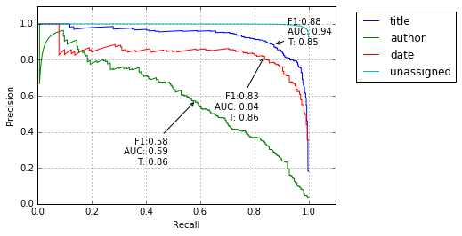

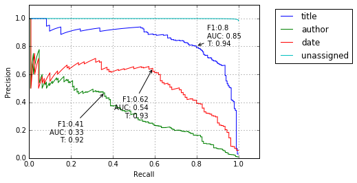

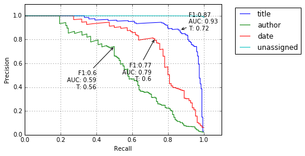

```python
pr_curve(y_train, pred_train)
pr_curve(y_test, predictions_nn1)
pr_curve(y_test, predictions_merge)
```

```python
eva.measure_performance(None, y_train, pred_train)
eva.measure_performance(None, y_test, predictions_nn1)
eva.measure_performance(None, y_test, predictions_merge)
```

```
Accuracy:0.902
             precision    recall  f1-score   support

      title       0.66      0.98      0.79       479
     author       0.24      0.89      0.38       283
       date       0.55      0.98      0.71       241
 unassigned       1.00      0.90      0.94     11890

avg / total       0.96      0.90      0.92     12893

[[  470     5     2     2]
 [    6   252     3    22]
 [    0     0   236     5]
 [  231   797   186 10676]]
Accuracy:0.892
             precision    recall  f1-score   support

      title       0.28      0.99      0.44       204
     author       0.07      0.90      0.12       144
       date       0.19      0.94      0.32       110
 unassigned       1.00      0.89      0.94     25201

avg / total       0.98      0.89      0.93     25659

[[  202     0     0     2]
 [    3   130     2     9]
 [    0     0   103     7]
 [  511  1814   432 22444]]
Accuracy:0.980
             precision    recall  f1-score   support

      title       0.59      0.97      0.73       204
     author       0.35      0.66      0.46       144
       date       0.41      0.83      0.55       110
 unassigned       1.00      0.98      0.99     25201

avg / total       0.99      0.98      0.98     25659

[[  198     0     0     6]
 [    3    95     2    44]
 [    0     0    91    19]
 [  134   176   130 24761]]
```

```python
evfrm[(evfrm['classifier']=='merge')&
      #(evfrm['method']=='thfmx')&
      (((evfrm['method']=='thfmx')&(evfrm['label']!=1))|
       ((evfrm['method']=='thrfil')&(evfrm['label']==1)))&
      (evfrm['set']==1)][['label','conf_t','conf_a','conf_d','conf_u']]\
.groupby('label').sum()
```

| label | conf_t | conf_a | conf_d | conf_u |
| --- | --- | --- | --- | --- |
| 0 | 696.0 | 0.0 | 0.0 | 174.0 |
| 1 | 1.0 | 133.0 | 10.0 | 336.0 |
| 2 | 0.0 | 0.0 | 290.0 | 110.0 |
| 3 | 106.0 | 58.0 | 16.0 | 117380.0 |

```python
evfrm[(evfrm['classifier']=='merge')&
      #(evfrm['method']=='thfmx')&
      (((evfrm['method']=='thfmx')&(evfrm['label']!=1))|
       ((evfrm['method']=='thrfil')&(evfrm['label']==1)))&
      (evfrm['set']==0)][['label','conf_t','conf_a','conf_d','conf_u']]\
.groupby('label').sum()[['conf_t','conf_a','conf_d','conf_u']]
```

| label | conf_t | conf_a | conf_d | conf_u |
| --- | --- | --- | --- | --- |
| 0 | 1548.0 | 0.0 | 0.0 | 342.0 |
| 1 | 0.0 | 595.0 | 8.0 | 578.0 |
| 2 | 0.0 | 0.0 | 641.0 | 325.0 |
| 3 | 125.0 | 205.0 | 67.0 | 236419.0 |

```python
prettyconfuse(evfrm[(evfrm['classifier']=='merge')&
      #(evfrm['method']=='thfmx')&
      (((evfrm['method']=='thfmx')&(evfrm['label']!=1))|
       ((evfrm['method']=='thrfil')&(evfrm['label']==1)))&
      (evfrm['set']==0)][['label','conf_t','conf_a','conf_d','conf_u']]\
.groupby('label').describe(percentiles=[])[['conf_t','conf_a','conf_d','conf_u']].round(1))
```

```
Title      155      0      0     34
Author       0     60      1     58
Date         0      0     64     32
Unass       12     20      7  23642
```

| label |  | conf_t | conf_a | conf_d | conf_u |
| --- | --- | --- | --- | --- | --- |
| 0 | count | 10.0 | 10.0 | 10.0 | 10.0 |
|  | mean | 154.8 | 0.0 | 0.0 | 34.2 |
|  | std | 4.5 | 0.0 | 0.0 | 4.5 |
|  | min | 149.0 | 0.0 | 0.0 | 29.0 |
|  | 50% | 155.0 | 0.0 | 0.0 | 34.0 |
|  | max | 160.0 | 0.0 | 0.0 | 40.0 |
| 1 | count | 10.0 | 10.0 | 10.0 | 10.0 |
|  | mean | 0.0 | 59.5 | 0.8 | 57.8 |
|  | std | 0.0 | 7.4 | 1.2 | 6.1 |
|  | min | 0.0 | 48.0 | 0.0 | 50.0 |
|  | 50% | 0.0 | 60.0 | 0.5 | 60.0 |
|  | max | 0.0 | 75.0 | 4.0 | 65.0 |
| 2 | count | 10.0 | 10.0 | 10.0 | 10.0 |
|  | mean | 0.0 | 0.0 | 64.1 | 32.5 |
|  | std | 0.0 | 0.0 | 6.4 | 5.2 |
|  | min | 0.0 | 0.0 | 56.0 | 22.0 |
|  | 50% | 0.0 | 0.0 | 63.0 | 33.0 |
|  | max | 0.0 | 0.0 | 75.0 | 39.0 |
| 3 | count | 10.0 | 10.0 | 10.0 | 10.0 |
|  | mean | 12.5 | 20.5 | 6.7 | 23641.9 |
|  | std | 4.0 | 4.6 | 2.6 | 1289.6 |
|  | min | 7.0 | 11.0 | 2.0 | 21423.0 |
|  | 50% | 12.0 | 21.0 | 7.0 | 23829.5 |
|  | max | 21.0 | 28.0 | 11.0 | 25660.0 |

## Results for Evaluationset

```python
prettyclass(evfrm[(evfrm['classifier']=='merge')&
      #(evfrm['method']=='thfmx')&
      (((evfrm['method']=='thfmx')&(evfrm['label']!=1))|
       ((evfrm['method']=='thrfil')&(evfrm['label']==1)))&
      (evfrm['set']==1)][['label','precision','recall','f1','support']]\
.groupby('label').describe(percentiles=[])[['precision','recall','f1','support']].round(2))
```

```
Label     Precision Recall    F1        Support
Title           0.87       0.8      0.83      87.0
Author          0.67      0.28      0.39      48.0
Date            0.92      0.72      0.81      40.0
Unass           0.99       1.0       1.0   11756.0
```

| label |  | precision | recall | f1 | support |
| --- | --- | --- | --- | --- | --- |
| 0 | count | 10.00 | 10.00 | 10.00 | 10.0 |
|  | mean | 0.87 | 0.80 | 0.83 | 87.0 |
|  | std | 0.02 | 0.02 | 0.02 | 0.0 |
|  | min | 0.84 | 0.78 | 0.81 | 87.0 |
|  | 50% | 0.87 | 0.79 | 0.83 | 87.0 |
|  | max | 0.89 | 0.83 | 0.86 | 87.0 |
| 1 | count | 10.00 | 10.00 | 10.00 | 10.0 |
|  | mean | 0.67 | 0.28 | 0.39 | 48.0 |
|  | std | 0.14 | 0.02 | 0.02 | 0.0 |
|  | min | 0.45 | 0.23 | 0.34 | 48.0 |
|  | 50% | 0.67 | 0.29 | 0.39 | 48.0 |
|  | max | 0.92 | 0.29 | 0.41 | 48.0 |
| 2 | count | 10.00 | 10.00 | 10.00 | 10.0 |
|  | mean | 0.92 | 0.72 | 0.81 | 40.0 |
|  | std | 0.02 | 0.02 | 0.02 | 0.0 |
|  | min | 0.88 | 0.68 | 0.78 | 40.0 |
|  | 50% | 0.92 | 0.72 | 0.82 | 40.0 |
|  | max | 0.94 | 0.75 | 0.83 | 40.0 |
| 3 | count | 10.00 | 10.00 | 10.00 | 10.0 |
|  | mean | 0.99 | 1.00 | 1.00 | 11756.0 |
|  | std | 0.00 | 0.00 | 0.00 | 0.0 |
|  | min | 0.99 | 1.00 | 1.00 | 11756.0 |
|  | 50% | 0.99 | 1.00 | 1.00 | 11756.0 |
|  | max | 1.00 | 1.00 | 1.00 | 11756.0 |

```python
prettyconfuse(evfrm[(evfrm['classifier']=='merge')&
      #(evfrm['method']=='thfmx')&
      (((evfrm['method']=='thfmx')&(evfrm['label']!=1))|
       ((evfrm['method']=='thrfil')&(evfrm['label']==1)))&
      (evfrm['set']==1)][['label','conf_t','conf_a','conf_d','conf_u']]\
.groupby('label').describe(percentiles=[])[['conf_t','conf_a','conf_d','conf_u']].round(1))
```

```
Title       70      0      0     17
Author       0     13      1     34
Date         0      0     29     11
Unass       11      6      2  11738
```

| label |  | conf_t | conf_a | conf_d | conf_u |
| --- | --- | --- | --- | --- | --- |
| 0 | count | 10.0 | 10.0 | 10.0 | 10.0 |
|  | mean | 69.6 | 0.0 | 0.0 | 17.4 |
|  | std | 1.3 | 0.0 | 0.0 | 1.3 |
|  | min | 68.0 | 0.0 | 0.0 | 15.0 |
|  | 50% | 69.0 | 0.0 | 0.0 | 18.0 |
|  | max | 72.0 | 0.0 | 0.0 | 19.0 |
| 1 | count | 10.0 | 10.0 | 10.0 | 10.0 |
|  | mean | 0.1 | 13.3 | 1.0 | 33.6 |
|  | std | 0.3 | 1.1 | 0.0 | 1.0 |
|  | min | 0.0 | 11.0 | 1.0 | 33.0 |
|  | 50% | 0.0 | 14.0 | 1.0 | 33.0 |
|  | max | 1.0 | 14.0 | 1.0 | 36.0 |
| 2 | count | 10.0 | 10.0 | 10.0 | 10.0 |
|  | mean | 0.0 | 0.0 | 29.0 | 11.0 |
|  | std | 0.0 | 0.0 | 0.9 | 0.9 |
|  | min | 0.0 | 0.0 | 27.0 | 10.0 |
|  | 50% | 0.0 | 0.0 | 29.0 | 11.0 |
|  | max | 0.0 | 0.0 | 30.0 | 13.0 |
| 3 | count | 10.0 | 10.0 | 10.0 | 10.0 |
|  | mean | 10.6 | 5.8 | 1.6 | 11738.0 |
|  | std | 1.3 | 2.9 | 0.7 | 3.5 |
|  | min | 9.0 | 1.0 | 1.0 | 11734.0 |
|  | 50% | 10.5 | 6.0 | 1.5 | 11737.0 |
|  | max | 13.0 | 11.0 | 3.0 | 11743.0 |

## raw NN1

```python
prettyclass(evfrm[(evfrm['classifier']=='merge')&(evfrm['method']=='raw')&
      (evfrm['set']==0)][['label','precision','recall','f1','support']]\
.groupby('label').describe(percentiles=[])[['precision','recall','f1','support']].round(2))
print('---')
prettyconfuse(evfrm[(evfrm['classifier']=='nn')&(evfrm['method']=='raw')&
      (evfrm['set']==0)][['label','conf_t','conf_a','conf_d','conf_u']]\
.groupby('label').describe(percentiles=[])[['conf_t','conf_a','conf_d','conf_u']].round(1))

#2624/23780 = 0.1103
```

```
Label     Precision Recall    F1        Support
Title           0.67      0.93      0.78     189.0
Author          0.32      0.67      0.42     118.1
Date            0.35       0.9       0.5      96.6
Unass            1.0      0.98      0.99   23681.6
---
Title      182      3      0      4
Author       2    101      1     13
Date         0      0     94      3
Unass      330   1650    618  21082
```

| label |  | conf_t | conf_a | conf_d | conf_u |
| --- | --- | --- | --- | --- | --- |
| 0 | count | 10.0 | 10.0 | 10.0 | 10.0 |
|  | mean | 181.9 | 2.6 | 0.5 | 4.0 |
|  | std | 5.0 | 2.1 | 0.8 | 4.0 |
|  | min | 173.0 | 0.0 | 0.0 | 0.0 |
|  | 50% | 183.0 | 2.5 | 0.0 | 3.0 |
|  | max | 189.0 | 7.0 | 2.0 | 13.0 |
| 1 | count | 10.0 | 10.0 | 10.0 | 10.0 |
|  | mean | 2.3 | 101.1 | 1.4 | 13.3 |
|  | std | 1.3 | 8.5 | 1.3 | 5.4 |
|  | min | 0.0 | 88.0 | 0.0 | 3.0 |
|  | 50% | 3.0 | 102.5 | 1.5 | 13.0 |
|  | max | 4.0 | 115.0 | 4.0 | 21.0 |
| 2 | count | 10.0 | 10.0 | 10.0 | 10.0 |
|  | mean | 0.0 | 0.0 | 93.9 | 2.7 |
|  | std | 0.0 | 0.0 | 7.9 | 1.8 |
|  | min | 0.0 | 0.0 | 82.0 | 1.0 |
|  | 50% | 0.0 | 0.0 | 93.5 | 2.5 |
|  | max | 0.0 | 0.0 | 107.0 | 6.0 |
| 3 | count | 10.0 | 10.0 | 10.0 | 10.0 |
|  | mean | 330.3 | 1650.5 | 618.3 | 21082.5 |
|  | std | 141.0 | 353.4 | 129.9 | 1359.6 |
|  | min | 168.0 | 1158.0 | 391.0 | 18118.0 |
|  | 50% | 307.0 | 1611.5 | 602.5 | 21447.5 |
|  | max | 640.0 | 2423.0 | 883.0 | 22643.0 |

```python
prettyclass(evfrm[(evfrm['classifier']=='merge')&(evfrm['method']=='raw')&
      (evfrm['set']==1)][['label','precision','recall','f1','support']]\
.groupby('label').describe(percentiles=[])[['precision','recall','f1','support']].round(2))
print('---')
prettyconfuse(evfrm[(evfrm['classifier']=='nn')&(evfrm['method']=='raw')&
      (evfrm['set']==1)][['label','conf_t','conf_a','conf_d','conf_u']]\
.groupby('label').describe(percentiles=[])[['conf_t','conf_a','conf_d','conf_u']].round(1))

#1251/11931 = 0.1048
```

```
Label     Precision Recall    F1        Support
Title           0.65      0.91      0.76      87.0
Author          0.28      0.57      0.37      48.0
Date            0.29      0.86      0.43      40.0
Unass            1.0      0.98      0.99   11756.0
---
Title       84      0      0      2
Author       2     40      2      4
Date         0      0     38      2
Unass      146    828    265  10518
```

| label |  | conf_t | conf_a | conf_d | conf_u |
| --- | --- | --- | --- | --- | --- |
| 0 | count | 10.0 | 10.0 | 10.0 | 10.0 |
|  | mean | 84.3 | 0.5 | 0.0 | 2.2 |
|  | std | 1.3 | 0.7 | 0.0 | 1.5 |
|  | min | 82.0 | 0.0 | 0.0 | 0.0 |
|  | 50% | 84.5 | 0.0 | 0.0 | 2.0 |
|  | max | 86.0 | 2.0 | 0.0 | 4.0 |
| 1 | count | 10.0 | 10.0 | 10.0 | 10.0 |
|  | mean | 2.1 | 39.6 | 2.0 | 4.3 |
|  | std | 0.7 | 1.0 | 0.0 | 1.2 |
|  | min | 1.0 | 38.0 | 2.0 | 3.0 |
|  | 50% | 2.0 | 39.5 | 2.0 | 4.0 |
|  | max | 3.0 | 41.0 | 2.0 | 6.0 |
| 2 | count | 10.0 | 10.0 | 10.0 | 10.0 |
|  | mean | 0.3 | 0.0 | 37.5 | 2.2 |
|  | std | 0.7 | 0.0 | 0.7 | 0.6 |
|  | min | 0.0 | 0.0 | 36.0 | 1.0 |
|  | 50% | 0.0 | 0.0 | 38.0 | 2.0 |
|  | max | 2.0 | 0.0 | 38.0 | 3.0 |
| 3 | count | 10.0 | 10.0 | 10.0 | 10.0 |
|  | mean | 145.6 | 827.7 | 265.1 | 10517.6 |
|  | std | 48.2 | 199.0 | 56.0 | 210.9 |
|  | min | 84.0 | 618.0 | 191.0 | 10040.0 |
|  | 50% | 149.5 | 813.5 | 253.0 | 10592.5 |
|  | max | 235.0 | 1286.0 | 381.0 | 10711.0 |

## Graphics

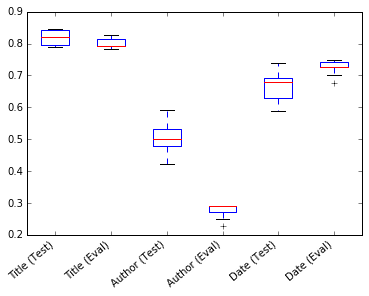

```python
tmp = evfrm[(evfrm['classifier']=='merge')&
                # (evfrm['method']=='thfmx')&
               (((evfrm['method']=='thfmx')&(evfrm['label']!=1))|
                ((evfrm['method']=='thrfil')&(evfrm['label']==1)))&
               (evfrm['set']==0)]
tmp2 = evfrm[(evfrm['classifier']=='merge')&
             # (evfrm['method']=='thfmx')&
             (((evfrm['method']=='thfmx')&(evfrm['label']!=1))|
              ((evfrm['method']=='thrfil')&(evfrm['label']==1)))&
             (evfrm['set']==1)]

plt.clf()

plt.boxplot([tmp[tmp['label']==0][['recall']].as_matrix(),
                 tmp2[tmp2['label']==0][['recall']].as_matrix(),
                 tmp[tmp['label']==1][['recall']].as_matrix(),
                 tmp2[tmp2['label']==1][['recall']].as_matrix(),
                 tmp[tmp['label']==2][['recall']].as_matrix(),
                 tmp2[tmp2['label']==2][['recall']].as_matrix()])
plt.xticks(range(1,7), ['Title (Test)', 'Title (Eval)',
                               'Author (Test)', 'Author (Eval)',
                               'Date (Test)', 'Date (Eval)'],rotation=40, ha='right')
plt.show()
```

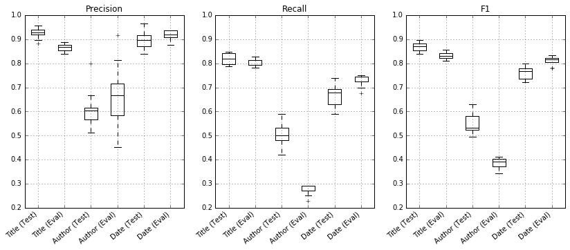

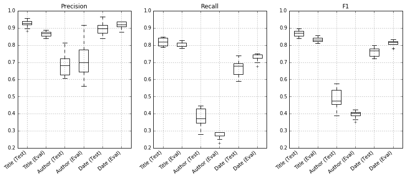

```python
plt.clf()

for tmp, tmp2 in [(
        evfrm[(evfrm['classifier']=='merge')&
              (((evfrm['method']=='thfmx')&(evfrm['label']!=1))|
               ((evfrm['method']=='thrfil')&(evfrm['label']==1)))&
              (evfrm['set']==0)],
        evfrm[(evfrm['classifier']=='merge')&
              (((evfrm['method']=='thfmx')&(evfrm['label']!=1))|
               ((evfrm['method']=='thrfil')&(evfrm['label']==1)))&
              (evfrm['set']==1)]
    ), (
        evfrm[(evfrm['classifier']=='merge')&
              (evfrm['method']=='thfmx')&
              (evfrm['set']==0)],
        evfrm[(evfrm['classifier']=='merge')&
              (evfrm['method']=='thfmx')&
              (evfrm['set']==1)]
    )]:
    f, axarr = plt.subplots(1,3, figsize=(14,5), squeeze=False)
    bp = axarr[0, 0].boxplot([tmp[tmp['label']==0][['precision']].as_matrix(),
                 tmp2[tmp2['label']==0][['precision']].as_matrix(),
                 tmp[tmp['label']==1][['precision']].as_matrix(),
                 tmp2[tmp2['label']==1][['precision']].as_matrix(),
                 tmp[tmp['label']==2][['precision']].as_matrix(),
                 tmp2[tmp2['label']==2][['precision']].as_matrix()],
                       labels=['Title (Test)', 'Title (Eval)',
                               'Author (Test)', 'Author (Eval)',
                               'Date (Test)', 'Date (Eval)'])
    axarr[0, 0].set_title('Precision')
    axarr[0, 0].set_ylim(0.2,1)
    axarr[0, 0].grid()
    plt.setp(bp['medians'], color='black')
    plt.setp(bp['boxes'], color='black')
    plt.setp(bp['fliers'], color='black')
    plt.setp(bp['whiskers'], color='black')

    bp = axarr[0, 1].boxplot([tmp[tmp['label']==0][['recall']].as_matrix(),
                 tmp2[tmp2['label']==0][['recall']].as_matrix(),
                 tmp[tmp['label']==1][['recall']].as_matrix(),
                 tmp2[tmp2['label']==1][['recall']].as_matrix(),
                 tmp[tmp['label']==2][['recall']].as_matrix(),
                 tmp2[tmp2['label']==2][['recall']].as_matrix()],
                       labels=['Title (Test)', 'Title (Eval)',
                               'Author (Test)', 'Author (Eval)',
                               'Date (Test)', 'Date (Eval)'])
    axarr[0, 1].set_title('Recall')
    axarr[0, 1].grid()
    axarr[0, 1].set_ylim(0.2,1)
    plt.setp(bp['medians'], color='black')
    plt.setp(bp['boxes'], color='black')
    plt.setp(bp['fliers'], color='black')
    plt.setp(bp['whiskers'], color='black')

    bp = axarr[0, 2].boxplot([tmp[tmp['label']==0][['f1']].as_matrix(),
                 tmp2[tmp2['label']==0][['f1']].as_matrix(),
                 tmp[tmp['label']==1][['f1']].as_matrix(),
                 tmp2[tmp2['label']==1][['f1']].as_matrix(),
                 tmp[tmp['label']==2][['f1']].as_matrix(),
                 tmp2[tmp2['label']==2][['f1']].as_matrix()],
                       labels=['Title (Test)', 'Title (Eval)',
                               'Author (Test)', 'Author (Eval)',
                               'Date (Test)', 'Date (Eval)'])
    axarr[0, 2].set_title('F1')
    axarr[0, 2].set_ylim(0.2,1)
    axarr[0, 2].grid()
    plt.setp(bp['medians'], color='black')
    plt.setp(bp['boxes'], color='black')
    plt.setp(bp['fliers'], color='black')
    plt.setp(bp['whiskers'], color='black')

    plt.setp(axarr[0, 0].get_xticklabels(), rotation=40, ha='right')
    plt.setp(axarr[0, 1].get_xticklabels(), rotation=40, ha='right')
    plt.setp(axarr[0, 2].get_xticklabels(), rotation=40, ha='right')

    plt.show()
```